# Coursework 1 - Supervised learning

# Outline

- Task 1: Regression
  - (1.1) Random Forest
    - (1.1.1)
    - (1.1.2)
    - (1.1.3)
  - (1.2) Multi-layer Perceptron
    - (1.2.1)
    - (1.2.2)
    - (1.2.3)
- Task 2: Classification
  - (2.1) k-Nearest Neighbours
    - (2.1.1)
    - (2.1.2)
    - (2.1.3)
  - (2.2) Logistic regression vs kernel logistic regression
    - (2.2.1)
    - (2.2.2)
    - (2.2.3)

```python
# Import necessary libraries
import numpy as np
import matplotlib.pyplot as plt
import seaborn as sns
import pandas as pd
from collections import defaultdict
import random

# Set seed for reproducibility
np.random.seed(42)
rng = np.random.default_rng(42)

# Initial global configuration for matplotlib
SMALL_SIZE = 12
MEDIUM_SIZE = 16
BIGGER_SIZE = 20

plt.rc('font', size=SMALL_SIZE)          # controls default text sizes
plt.rc('axes', titlesize=SMALL_SIZE)     # fontsize of the axes title
plt.rc('axes', labelsize=MEDIUM_SIZE)    # fontsize of the x and y labels
plt.rc('xtick', labelsize=SMALL_SIZE)    # fontsize of the tick labels
plt.rc('ytick', labelsize=SMALL_SIZE)    # fontsize of the tick labels
plt.rc('legend', fontsize=SMALL_SIZE)    # legend fontsize
plt.rc('figure', titlesize=BIGGER_SIZE)  # fontsize of the figure title
```

# (1) Task 1: Regression (index)

```python
nanodf = pd.read_csv("nanoelectrodes_capacitance_samples.csv")
nano_test_df = pd.read_csv("nanoelectrodes_capacitance_test.csv")


# retrieve all rows, all columns except target variable (as pd dataframe)
X_train = nanodf.loc[:,nanodf.columns != 'Capacitance ($\mu F / cm^2$)']
y_train = nanodf.loc[:, nanodf.columns == 'Capacitance ($\mu F / cm^2$)']
print("X_train shape: ", X_train.shape)
print("y_train shape: ", y_train.shape)

X_test = nano_test_df.loc[:,nanodf.columns != 'Capacitance ($\mu F / cm^2$)']
y_test = nano_test_df.loc[:, nanodf.columns == 'Capacitance ($\mu F / cm^2$)']
print("X_test shape: ", X_test.shape)
print("y_testshape: ", y_test.shape)

nanodf.head()
```

```
X_train shape:  (558, 12)
y_train shape:  (558, 1)
X_test shape:  (62, 12)
y_testshape:  (62, 1)
```

|  | Surface_Area ($m^2/g$) | Defect_Ratio | Doped_Nitrogen_Percentage | Doped_Oxygen_Percentage | Doped_Sulfur_Percentage | Current_Density ($A/g$) | Capacitance ($\mu F / cm^2$) | Electrolyte_Concentration $[M]$ | H9_Factor ($mL/g$) | T5_Factor ($mL/g$) | Doped_Zinc_Percentage | Doped_Flourine_Percentage | Doped_Carbon_Percentage |
| --- | --- | --- | --- | --- | --- | --- | --- | --- | --- | --- | --- | --- | --- |
| 0 | 96.78 | 1.30 | 0.933333 | 19.690000 | 0.843333 | 6.0 | 173.0 | 6.0 | 11.188890 | 33.753753 | 80.542095 | 46.933213 | 50.199105 |
| 1 | 531.90 | 1.28 | 7.700000 | 13.700000 | 8.300000 | 5.0 | 298.5 | 6.0 | 54.206536 | 25.721984 | 36.506123 | 44.773787 | 19.238604 |
| 2 | 438.70 | 1.27 | 5.030000 | 4.760000 | 3.710000 | 2.0 | 404.0 | 2.0 | 46.425494 | 11.422661 | 45.927300 | 59.097544 | 67.537988 |
| 3 | 149.32 | 1.02 | 1.240000 | 15.450000 | 3.030000 | 0.3 | 299.7 | 6.0 | 16.322920 | 9.179250 | 69.495872 | 35.124313 | 62.494312 |
| 4 | 1484.00 | 0.84 | 5.740000 | 6.993333 | 0.386667 | 5.0 | 250.0 | 1.0 | 152.864772 | 29.174519 | 61.365160 | 50.942724 | 77.980072 |

## (1.1) Random Forest (index)

### (1.1.1) (index)

To train a decision tree regression model on the training set "nanoelectrodes_capacitance_samples.csv", with given hyperparameters.

We do not standardize our datasets as decision tree is not sensitive to differences in scale or centering of the input features.

Note we are building a regression tree here, so cannot use gini index to decide split_value.

Instead we use the MSE(y) / var(y) for split value, (MSE of using mean to estimate y), as coded in loss() below

```python
'''Define necessary functions for decision tree'''
def loss(y, sample_weights):
    '''This is the gini index / MSE / Var of y'''
    total_weight = sum(sample_weights)
    mean_y = sum(wi * yi for yi, wi in zip(y, sample_weights)) / total_weight

    sum_squared_error = sum(wi * (yi - mean_y)**2 for yi, wi in zip(y, sample_weights))
    return sum_squared_error / total_weight

def split_samples(X, y, sample_weights, column, value, categorical):
    if categorical:
        left_mask =(X[:, column] == value)
    else:
        left_mask = (X[:, column] < value)

    X_l, y_l, w_l = X[left_mask, :], y[left_mask], sample_weights[left_mask]
    X_r, y_r, w_r = X[~left_mask, :], y[~left_mask], sample_weights[~left_mask]

    return (X_l, y_l, w_l), (X_r, y_r, w_r)

def split_value(X, y, sample_weights, column, categorical):
    '''Find best value for split'''
    unique_vals = np.unique(X[:, column])
    cost, s = np.inf, None
    for value in unique_vals:
        (X_l, y_l, w_l), (X_r, y_r, w_r) = split_samples(X, y, sample_weights, column, value, categorical)

        if len(y_l) == 0 or len(y_r) == 0: # if either side is empty, skip this split.
            continue

        p_left = sum(w_l)/(sum(w_l) + sum(w_r))
        p_right = 1 - p_left
        new_cost = p_left * loss(y_l, w_l) + p_right * loss(y_r, w_r)
        if new_cost < cost:
            cost, s = new_cost, value

    return cost, s

def split_js(X, y, sample_weights, columns_dict):
    '''Find best (j,s) to split'''
    min_loss = np.inf
    split_column = None # if None returned, there is no valid split at the current node.
    split_val = np.nan

    for column, categorical in columns_dict.items():
        # skip column if samples are not seperable by that column.
        if len(np.unique(X[:, column])) < 2:
            continue
        loss, s = split_value(X, y, sample_weights, column, categorical)

        if loss < min_loss: # this column more worth splitting than previous min_index
            min_loss = loss
            split_column = column
            split_val = s

    return split_column, split_val

def majority_vote(y, sample_weights):
    '''For regression tree, this is just y_mean of a leaf node'''
    total_weight = sum(sample_weights)
    mean_y = sum(wi * yi for yi, wi in zip(y, sample_weights)) / total_weight
    return mean_y

def build_tree(X, y, sample_weights, columns_dict, feature_names, depth,  max_depth=10, min_samples_leaf=10):
    # include a clause for the cases where (i) no feature, (ii) all labels are the same, (iii) depth exceed, or (iv) X is too small
    if len(np.unique(y))==1 or depth>=max_depth or len(X)<=min_samples_leaf:
        return {'Tree value': majority_vote(y, sample_weights)}

    split_index, split_val = split_js(X, y, sample_weights, columns_dict)

    # If no valid split at this node, use majority vote.
    if split_index is None:
        return {'Tree value': majority_vote(y, sample_weights)}

    categorical = columns_dict[split_index]

    # Split samples (X, y, sample_weights) given column, split-value, and categorical flag.
    (X_l, y_l, w_l), (X_r, y_r, w_r) = split_samples(X, y, sample_weights, split_index, split_val, categorical)
    return {
        'feature_name': feature_names[split_index],
        'feature_index': split_index,
        'value': split_val,
        'categorical': categorical,
        'Tree value': None,
        'left': build_tree(X_l, y_l, w_l, columns_dict, feature_names, depth + 1, max_depth, min_samples_leaf),
        'right': build_tree(X_r, y_r, w_r, columns_dict, feature_names, depth + 1, max_depth, min_samples_leaf)
    }

def train(X, y,  columns_dict, sample_weights=None, max_depth=10, min_samples_leaf=10):
    if sample_weights is None:
        # if the sample weights is not provided, we assume the samples have uniform weights
        sample_weights = np.ones(X.shape[0]) / X.shape[0]
    else:
        sample_weights = np.array(sample_weights) / np.sum(sample_weights)

    feature_names = X.columns.tolist()
    X = X.to_numpy()
    y = y.to_numpy()
    return build_tree(X, y, sample_weights, columns_dict, feature_names, depth=1, max_depth = max_depth, min_samples_leaf = min_samples_leaf)

def predict_sample(tree, x):
    if tree['Tree value'] is not None:
        return tree['Tree value']

    elif tree['categorical']:
        if x[tree['feature_index']] == tree['value']:
            return predict_sample(tree['left'], x)
        else:
            return predict_sample(tree['right'], x)

    else: # continuous data
        if x[tree['feature_index']] < tree['value']:
            # go to left branch
            return predict_sample(tree['left'], x)
        else:
            # go to right branch
            return predict_sample(tree['right'], x)

def predict(tree, X):
    return [predict_sample(tree, x) for x in X]
```

```python
'''Initial loss before applying tree.'''
# Assume all features have the same weight.
training_weights = np.ones_like(y_train) / len(y_train)
loss(y_train.to_numpy(), training_weights)
```

```
array([6627.27006727])
```

```python
'''Train tree and make prediction'''

# Assume all features have the same weight.
training_weights = np.ones_like(y_train) / len(y_train)

# In this example, all features are numerical (categorical=False)
columns_dict = {index: False for index in range(X_train.shape[1])}
tree = train(X_train, y_train, columns_dict)
```

```python
'''Make predictions on both training and testing sets'''
y_train_pred = predict(tree, X_train.to_numpy())
y_train_pred = np.array(y_train_pred)

y_test_pred = predict(tree, X_test.to_numpy())
y_test_pred = np.array(y_test_pred)
y_train_pred.shape, y_test_pred.shape
```

```
((558, 1), (62, 1))
```

Evaluation on training and testing dataset with MSE and $R^2$ metric

```python
def MSE(y_true, y_pred):
    return np.mean((y_true - y_pred) ** 2)

def R_squared(y_true, y_pred):
    mean_y_true = np.mean(y_true)
    total_sum_of_squares = np.sum((y_true - mean_y_true) ** 2)
    residual_sum_of_squares = np.sum((y_true - y_pred) ** 2)
    return 1 - (residual_sum_of_squares / total_sum_of_squares)

print("Training MSE", MSE(y_train.to_numpy(), y_train_pred))
print("Training R squared", R_squared(y_train.to_numpy(), y_train_pred))

print("Testing MSE", MSE(y_test.to_numpy(), y_test_pred))
print("Testing R squared", R_squared(y_test.to_numpy(), y_test_pred))
```

```
Training MSE 1654.405150695157
Training R squared 0.7503640060081044
Testing MSE 3369.5671069811665
Testing R squared 0.4896216113769656
```

Discussion of findings: While decision tree is performing well on the training set, it fails to generalize well on testing set, with a very low $R^2$ score and much larger MSE.

### (1.1.2) (index)

```python
'''Modify decision tree functions to add bagging and feature bagging.'''
def split_js_rf(n_features, X, y, sample_weights, columns_dict):
    '''Find best (j,s) to split among n random features'''

    # finds n_features unique columns to split
    columns = rng.choice(list(columns_dict.keys()), n_features, replace=False)
    columns_dict = {c: columns_dict[c] for c in columns}

    min_loss = np.inf
    split_column = None
    split_val = np.nan

    for column, categorical in columns_dict.items():
        # skip column if samples are not seperable by that column.
        if len(np.unique(X[:, column])) < 2:
            continue
        loss, s = split_value(X, y, sample_weights, column, categorical)

        if loss < min_loss: # this column more worth splitting than previous min_index
            min_loss = loss
            split_column = column
            split_val = s

    return split_column, split_val

def build_tree_rf(n_features, X, y, sample_weights, columns_dict, feature_names, depth,  max_depth=10, min_samples_leaf=10):
    '''Same with build_tree except calls split_js_rf instead of split_js.'''
    # note here X and y can have duplicates (from bagging)
    if len(np.unique(y))==1 or depth>=max_depth or len(X)<=min_samples_leaf:
        return {'Tree value': majority_vote(y, sample_weights)}

    split_index, split_val = split_js_rf(n_features, X, y, sample_weights, columns_dict)
    if split_index is None:
        return {'Tree value': majority_vote(y, sample_weights)}

    categorical = columns_dict[split_index]
    (X_l, y_l, w_l), (X_r, y_r, w_r) = split_samples(X, y, sample_weights, split_index, split_val, categorical)
    return {
        'feature_name': feature_names[split_index],
        'feature_index': split_index,
        'value': split_val,
        'categorical': categorical,
        'Tree value': None,
        'left': build_tree_rf(n_features, X_l, y_l, w_l, columns_dict, feature_names, depth + 1, max_depth, min_samples_leaf),
        'right': build_tree_rf(n_features, X_r, y_r, w_r, columns_dict, feature_names, depth + 1, max_depth, min_samples_leaf)
    }

def train_rf(B, n_features, X, y, columns_dict, sample_weights = None, max_depth=10, min_samples_leaf=10, oob=False):
    '''If oob=True, return list of trees as well as oob samples of each tree.'''
    if sample_weights is None:
        # if the sample weights is not provided, we assume the samples have uniform weights
        sample_weights = np.ones(X.shape[0]) / X.shape[0]
    else:
        sample_weights = np.array(sample_weights) / np.sum(sample_weights)

    feature_names = X.columns.tolist()
    X = X.to_numpy()
    y = y.to_numpy()
    N = X.shape[0]
    training_indices = np.arange(N)
    trees = []

    for _ in range(B):
        sample = np.random.choice(training_indices, N, replace=True) # bagging
        X_sample = X[sample, :]
        y_sample = y[sample]
        oob_indices = np.setdiff1d(training_indices, sample) # unique unchosen indices
        X_oob = X[oob_indices, :]
        y_oob = y[oob_indices, :]
        w_sample = sample_weights[sample]
        tree = build_tree_rf(n_features, X_sample, y_sample, w_sample,
                             columns_dict, feature_names, depth=1, max_depth=max_depth, min_samples_leaf=min_samples_leaf)
        if oob:
            trees.append((tree, X_oob, y_oob))
        else:
            trees.append(tree)

    return trees

def predict_rf(rf, X, oob=False):
    '''Return the mean of all trees for prediction. if oob, return prediction for x_oob.'''
    if oob:
        # should not call predict_rf if oob.
        return
    predictions = []
    for tree in rf:
        predictions.append(predict(tree, X))
    return np.mean(predictions, axis=0)
```

The standard rule-of-thumb for n_features is p/3, where p is the total number of features for X. In this case X has 12 features, so we use n_feature $ = 4$

We use 5-fold cross-validation to determine B.

```python
'''Use 5-fold cross validation to find optimal value of B.'''
def cross_val_split(N, k):
    """Split the indices of the dataset into k folds."""
    fold_size = N // k
    index_perm = rng.permutation(np.arange(N))
    folds = []
    for i in range(k):
        start_idx = i * fold_size
        end_idx = (i+1) * fold_size
        folds.append(index_perm[start_idx : end_idx])
    return folds

# shuffle
p = rng.permutation(len(y_train))
X_train_shuffled = X_train.iloc[p, :]
y_train_shuffled = y_train.iloc[p]

# Five fold cross-validation
folds_indexes = cross_val_split(len(y_train), 5)

forest_size = [10, 20, 30, 40, 50]
mse_vals = []
for b in forest_size:
    mse_scores = []
    for fold in folds_indexes:
        # Split the data into training and validation
        X_val_fold = X_train_shuffled.iloc[fold, :]
        y_val_fold = y_train_shuffled.iloc[fold]
        # use every other rows to train
        X_train_fold = X_train_shuffled.drop(fold, axis=0)
        y_train_fold = y_train_shuffled.drop(fold, axis=0)

        # Train the random forest on train_fold, then evaluate on val_fold
        # we set n_features = 4 for feature bagging
        rf = train_rf(b, 4, X_train_fold, y_train_fold, columns_dict)
        y_val_fold_pred = predict_rf(rf, X_val_fold.to_numpy())
        mse = MSE(y_val_fold.to_numpy(), y_val_fold_pred)
        mse_scores.append(mse)
    mse_vals.append(np.mean(mse_scores))
print(mse_vals)
```

```
[1863.015536125334, 1672.702880811267, 1706.2971848780883, 1595.9024254736298, 1641.9608400934983]
```

```python
optimal_B = forest_size[np.argmin(mse_vals)]
optimal_B
```

```
40
```

We can see that with B = 40, we have the lowest MSE of 1595, out of choices of 10, 20, 30, 40 and 50.

Then we will evaluate its MSE and $R^2$ on the testing set.

```python
'''Use random forest to make predictions on both training and testing sets.'''

# train rf with B = 40 on the whole training set
B = 40
rf = train_rf(B, 4, X_train, y_train, columns_dict)
y_train_pred = np.array(predict_rf(rf, X_train.to_numpy()))

y_test_pred = np.array(predict_rf(rf, X_test.to_numpy()))

print("Training MSE", MSE(y_train.to_numpy(), y_train_pred))
print("Training R squared", R_squared(y_train.to_numpy(), y_train_pred))

print("Testing MSE", MSE(y_test.to_numpy(), y_test_pred))
print("Testing R squared", R_squared(y_test.to_numpy(), y_test_pred))
```

```
Training MSE 1287.8094734200092
Training R squared 0.8056802483754957
Testing MSE 3220.187948205481
Testing R squared 0.5122476318505875
```

Now keeping B = 40 fixed, train another rf without feature bagging and compare their performances on the test set.

```python
'''Use random forest without feature bagging on both training and testing sets.'''

# train rf with B = 40 on the whole training set
B = 40
rf = train_rf(B, 12, X_train, y_train, columns_dict)
y_train_pred = np.array(predict_rf(rf, X_train.to_numpy()))

y_test_pred = np.array(predict_rf(rf, X_test.to_numpy()))

print("Training MSE", MSE(y_train.to_numpy(), y_train_pred))
print("Training R squared", R_squared(y_train.to_numpy(), y_train_pred))

print("Testing MSE", MSE(y_test.to_numpy(), y_test_pred))
print("Testing R squared", R_squared(y_test.to_numpy(), y_test_pred))
```

```
Training MSE 1117.8755865621974
Training R squared 0.831321860250816
Testing MSE 3018.626881676603
Testing R squared 0.5427774919418186
```

### (1.1.3) (index)

Keeping B = 40 fixed, we want to search for optimal values of max_depth and min_samples_leaf.

We will perform grid search on every combination of (tree depth, leaf_size) taking values from [4, 6, 8, 10, 12, 14].

With each hyperparameter pair, we will evaluate the rf's performance with 5-fold cross-validation using MSE metric.

```python
B = 40
tree_depth = [4, 6, 8, 10, 12, 14]
leaf_size = [4, 6, 8, 10, 12, 14]
mse_grid_search = {}
# shuffle
p = rng.permutation(len(y_train))
X_train_shuffled = X_train.iloc[p, :]
y_train_shuffled = y_train.iloc[p]
for i in tree_depth:
    for j in leaf_size:
        mse_scores = []
        for fold in folds_indexes:
            # Split the data into training and validation
            X_val_fold = X_train_shuffled.iloc[fold, :]
            y_val_fold = y_train_shuffled.iloc[fold]
            X_train_fold = X_train_shuffled.drop(fold, axis=0)
            y_train_fold = y_train_shuffled.drop(fold, axis=0)

            # Train the random forest on train_fold, then evaluate on val_fold
            rf = train_rf(B, 4, X_train_fold, y_train_fold, columns_dict, max_depth=i, min_samples_leaf=j)
            y_val_fold_pred = predict_rf(rf, X_val_fold.to_numpy())
            mse = MSE(y_val_fold, y_val_fold_pred)
            mse_scores.append(mse)
        mse_grid_search[(i,j)] = np.mean(mse_scores)
```

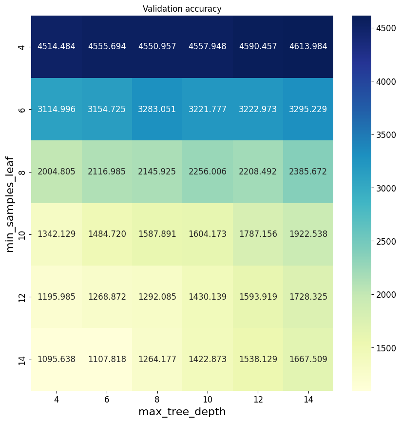

```python
# Plot grid search results
fig, ax = plt.subplots(figsize=(10, 10))
sns.heatmap(np.array(list(mse_grid_search.values())).reshape(6, 6), annot=True, ax=ax, cmap="YlGnBu", fmt=".3f", xticklabels=tree_depth, yticklabels=leaf_size)
ax.set_xlabel("max_tree_depth")
ax.set_ylabel("min_samples_leaf")
ax.set_title("Validation accuracy")
plt.show()
```

```python
'''Evaluate on test set with MSE and R^2.'''
B = 40
rf = train_rf(B, 4, X_train, y_train, columns_dict, min_samples_leaf=14, max_depth=4)
y_test_pred = np.array(predict_rf(rf, X_test.to_numpy()))
print("Testing MSE", MSE(y_test.to_numpy(), y_test_pred))
print("Testing R squared", R_squared(y_test.to_numpy(), y_test_pred))
```

```
Testing MSE 5297.256908156735
Testing R squared 0.19764012436319667
```

```python
y_train_pred = np.array(predict_rf(rf, X_train.to_numpy()))
print("Training MSE", MSE(y_train.to_numpy(), y_train_pred))
print("Training R squared", R_squared(y_train.to_numpy(), y_train_pred))
```

```
Training MSE 4497.635289699176
Training R squared 0.32134419692461147
```

Notice the testing MSE is much higher than the forest we built with min_samples_leaf=10 and max_depth = 10. $R^2$ is also much lower.

For a clearer comparison, I have trained another forest with min_samples_leaf=10 and max_depth = 10 below, and we observe that it is performing much better on the testing set.

```python
'''Evaluate on test set with MSE and R^2.'''
B = 40
rf = train_rf(B, 4, X_train, y_train, columns_dict, min_samples_leaf=10, max_depth=10)
y_test_pred = np.array(predict_rf(rf, X_test.to_numpy()))
print("Testing MSE", MSE(y_test.to_numpy(), y_test_pred))
print("Testing R squared", R_squared(y_test.to_numpy(), y_test_pred))
```

```
Testing MSE 3518.3862548617167
Testing R squared 0.46708041410145673
```

To calculate the importance of feature k, we find OOB accuracy of the rf with every feature, minus the OOB accuracy with feature k removed.

First define a function oob_accuracy() that calculates OOB accuracy given a list of trees from train_rf.

Note train_rf(oob = True) returns a list of trees with the corresponding oob samples of each. i.e. returns [(tree1, X_oob, y_oob), (tree2, X_oob, y_oob) ... ]

Oob accuracy is given by:

```python
B = 40
rf = train_rf(B, 4, X_train, y_train, columns_dict, min_samples_leaf=10, max_depth=10, oob=True)
```

```python
def oob_accuracy(rf, permute_feature =False, i=0):
    '''Evaluates each tree on its own oob, then average this MSE over all trees.'''
    # if permute_feature=True, permute the ith feature, then evaluate.
    oob_MSE = []
    for T in rf:
        tree, X_oob, y_oob = T
        if permute_feature:
            X_copy = np.copy(X_oob)
            rng.shuffle(X_copy[:,i])
            y_pred_oob = predict(tree, X_copy)
        else:
            y_pred_oob = predict(tree, X_oob)
        oob_MSE.append(MSE(y_pred_oob, y_oob))
        # print(MSE(y_pred_oob, y_oob))
    return np.mean(oob_MSE, axis=0)
```

```python
oob_original = oob_accuracy(rf)
oob_original
```

```
6513.931838174782
```

```python
feature_importance = []
for j in range(12):
    feature_importance.append(oob_accuracy(rf, permute_feature=True, i=j) - oob_original)
feature_importance
```

```
[2259.123153471068,
 1369.7931914702212,
 998.1292501035232,
 1694.4268872608955,
 608.6131882041627,
 907.605751107234,
 442.33563559843424,
 1538.188782742738,
 1083.003466563383,
 -72.34981781637816,
 -8.670071847488543,
 -27.982707803238554]
```

Note the last 3 features has negative importance, which may be due to random error, so we will just make it 0.

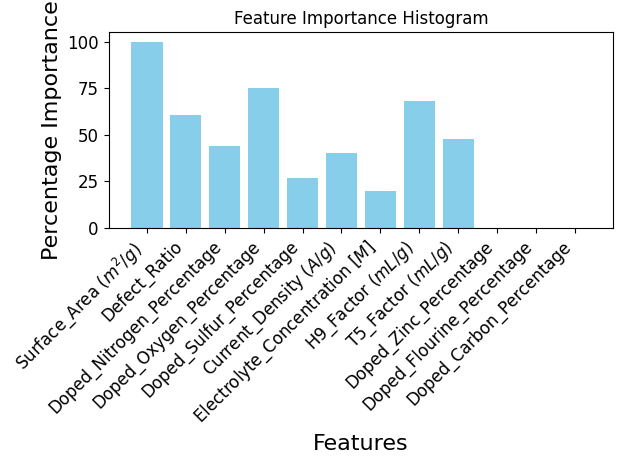

```python
feature_importance[9] = 0
feature_importance[10] = 0
feature_importance[11] = 0
percentages = [imp / np.max(feature_importance) * 100 for imp in feature_importance]
labels = X_train.columns.tolist()
plt.bar(labels, percentages, color='skyblue')
plt.xlabel('Features')
plt.ylabel('Percentage Importance')
plt.title('Feature Importance Histogram')
plt.xticks(rotation=45, ha='right')
plt.tight_layout()
plt.show()
```

## (1.2) Multi-layer Perceptron (index)

### (1.2.1) (index)

Before applying MLP, we need to standardise both X_train and X_test by the mean and variance of X_train.

```python
def standardise(X, X_train_=None):
    if X_train_ is None:
        X_train_ = X

    mu = np.mean(X_train_, axis=0, keepdims=True)
    sigma = np.std(X_train_, axis=0, keepdims=True)
    X_std = (X - mu) / sigma
    return X_std

X_test = standardise(X_test.to_numpy(), X_train_=X_train.to_numpy())
y_test = y_test.to_numpy()
X_train = standardise(X_train.to_numpy())
y_train = y_train.to_numpy()
```

The following code defines an MLP class consisting of 2 hidden dense layers and an output layer of one neuron, as instructed by the question. Both hidden layers are dense, have 50 neurons, and use activation function $$ \sigma(x) = \text{tan}^{-1} (x) \cdot \ln(|x| + 1) $$

The derivative of $\ln(|x| + 1)$ is $$ \begin{cases} \frac{1}{x+1} & \text{if } x > 0 \\ \frac{1}{x-1} & \text{if } x < 0 \end{cases} $$ It is not differentiable at x = 0

Hence derivative of the activation function is $$ \sigma'(x) = \begin{cases} \frac{\text{tan}^{-1}(x)}{x+1} + \frac{1}{1+x^2}\ln(x + 1) & \text{if } x > 0 \\ \frac{\text{tan}^{-1}(x)}{x-1} + \frac{1}{1+x^2}\ln(-x + 1)& \text{if } x < 0 \end{cases} $$

However the limit for $\sigma'(x)$ does exist at 0: $ \lim_{x \to 0} \sigma'(x) = 0 $, so we will take 0 as the value for backprop.

I used a simpler and more concise definition of MLP here, instead of the one provided in the Week 5 notebook.

```python
def activation(x):
    return np.arctan(x) * (np.log(np.abs(x) + 1))

def dadx(x):
    '''Gradient of activation.'''
    result = np.zeros_like(x)
    result[x>0] = np.arctan(x[x>0]) / (x[x>0] + 1) + np.log(np.abs(x[x>0]) + 1) / (1 + x[x>0] ** 2)
    result[x<0] = np.arctan(x[x<0]) / (x[x<0] - 1) + np.log(np.abs(x[x<0]) + 1) / (1 + x[x<0] ** 2)
    result[x==0] = 0
    return result

class MLP:
    def __init__(self, sizes):
        self.sizes = sizes
        self.biases = [np.random.randn(y, 1) for y in sizes[1:]]
        self.weights = [np.random.randn(y, x) * np.sqrt(2. / (x+y))
                        for x, y in zip(sizes[:-1], sizes[1:])]
        #  # apply Glorot initialisation for weights.
        #  "W": self.rng.normal(size=(out_dim, in_dim)) * np.sqrt(2. / (in_dim + out_dim)),

    def forward(self, a):
        """Forward call for one input vector "a"."""
        for b, w in zip(self.biases[:-1], self.weights[:-1]):
            a = activation(np.dot(w, a) + b)
        # no activation for output layer (regression)
        b_out, w_out = self.biases[-1], self.weights[-1]
        a = np.dot(w_out, a) + b_out
        return a

    def dMSE(self, y_pred, yi):
        '''Assume metric is MSE, this is dMSE/dy^i.'''
        return 2*(y_pred - yi)

    def backprop(self, xi, yi):
        xi, yi = xi.reshape(-1, 1), yi.reshape(-1,1)
        grad_b = [np.zeros(b.shape) for b in self.biases]
        grad_w = [np.zeros(w.shape) for w in self.weights]
        pre_a = []# list to store all the preactivations
        post_a = [xi] # list to store all the post_activations

        # forward pass
        z = xi
        for b, w in zip(self.biases[:-1], self.weights[:-1]):
            z = np.dot(w, z)+b
            pre_a.append(z)
            z = activation(z)
            post_a.append(z)
        # last layer without activation
        b_out, w_out = self.biases[-1], self.weights[-1]
        z = np.dot(w_out, z) + b_out # z is y_pred
        pre_a.append(z)

        # backward pass
        delta = self.dMSE(z, yi)
        grad_b[-1] = delta
        grad_w[-1] = np.dot(delta, post_a[-1].transpose())
        for l in range(2, len(self.sizes)):
            z = pre_a[-l]
            delta = np.dot(self.weights[-l+1].transpose(), delta) * dadx(z)
            grad_b[-l] = delta
            grad_w[-l] = np.dot(delta, post_a[-l].transpose())
        return (grad_b, grad_w)

    def sgd_one_batch(self, mini_batch, eta):
        """Update parameters by gradient descent on a single mini batch."""
        grad_b = [np.zeros(b.shape) for b in self.biases]
        grad_w = [np.zeros(w.shape) for w in self.weights]

        # computes gradient for every training sample in the mini_batch
        for xi, yi in mini_batch:
            # db denotes dli/db for all bias, same for dw
            db, dw = self.backprop(xi, yi)

            # elementwise addition of grads of bias and weights
            grad_b = [nb+dnb for nb, dnb in zip(grad_b, db)]
            grad_w = [nw+dnw for nw, dnw in zip(grad_w, dw)]

        # gradient descent (normalized by size of batch)
        self.weights = [w - eta/len(mini_batch) * dw  for w, dw in zip(self.weights, grad_w)]
        self.biases = [b - eta/len(mini_batch) * db for b, db in zip(self.biases, grad_b)]

    def SGD(self, training_data, epochs, mini_batch_size, eta):
        '''Devides into batches, and calls sgd_one_batch on every batch.'''
        # note training_data = zip(X_train, y_train).
        training_data = list(training_data) # turn zip to list
        n = len(training_data)

        train_loss = []
        test_loss = []
        for j in range(epochs):
            # shuffle x_train and y_train together
            random.shuffle(training_data)

            #partitions into mini-batches
            mini_batches = [
                training_data[k:k+mini_batch_size]
                for k in range(0, n, mini_batch_size)]

            for mini_batch in mini_batches:
                self.sgd_one_batch(mini_batch, eta) # sgd on one batch
            # complete pass through entire dataset
            print("Epoch {} complete".format(j))
            # evaluate performance on both x_train and x_test after each epoch
            # (note here X_train and y_train are not inputs to this function, but
            # predefined arrays in this jupyter notebook)


            train_loss.append(self.evaluate(X_train, y_train))
            test_loss.append(self.evaluate(X_test, y_test))

        return (train_loss, test_loss)

    def evaluate(self, x, y):
        y_pred = np.array([self.forward(xi.reshape(-1,1)) for xi in x])
        y_pred = np.squeeze(y_pred)
        y = np.squeeze(y)
        # So that both y and y_pred has (n, ) shape
        return MSE(y_pred, y)

    def predict(self, x):
        y_pred = np.array([self.forward(xi.reshape(-1,1)) for xi in x])
        return np.squeeze(y_pred)
```

BUild MLP as instructed: one input layer with 12 neurons (features), two hidden FC layers with 50 neurons each, output layer with one neuron.

```python
mlp = MLP([12,50,50,1])
training_data = zip(X_train, y_train)
train_loss, test_loss = mlp.SGD(training_data, epochs = 300, mini_batch_size = 8, eta = 5e-5)
# train_loss
```

```
Epoch 0 complete
Epoch 1 complete
Epoch 2 complete
Epoch 3 complete
Epoch 4 complete
Epoch 5 complete
Epoch 6 complete
Epoch 7 complete
Epoch 8 complete
Epoch 9 complete
Epoch 10 complete
Epoch 11 complete
Epoch 12 complete
Epoch 13 complete
Epoch 14 complete
Epoch 15 complete
Epoch 16 complete
Epoch 17 complete
Epoch 18 complete
Epoch 19 complete
Epoch 20 complete
Epoch 21 complete
Epoch 22 complete
Epoch 23 complete
Epoch 24 complete
Epoch 25 complete
Epoch 26 complete
Epoch 27 complete
Epoch 28 complete
Epoch 29 complete
Epoch 30 complete
Epoch 31 complete
Epoch 32 complete
Epoch 33 complete
Epoch 34 complete
Epoch 35 complete
Epoch 36 complete
Epoch 37 complete
Epoch 38 complete
Epoch 39 complete
```

[output cut: 245 more lines]

```
Epoch 285 complete
Epoch 286 complete
Epoch 287 complete
Epoch 288 complete
Epoch 289 complete
Epoch 290 complete
Epoch 291 complete
Epoch 292 complete
Epoch 293 complete
Epoch 294 complete
Epoch 295 complete
Epoch 296 complete
Epoch 297 complete
Epoch 298 complete
Epoch 299 complete
```

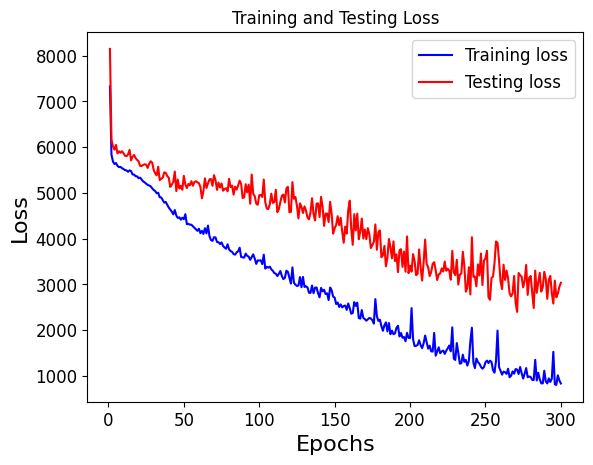

```python
epochs = range(1, 301)
plt.plot(epochs, train_loss, 'b', label='Training loss')
plt.plot(epochs, test_loss, 'r', label='Testing loss')
plt.title('Training and Testing Loss')
plt.xlabel('Epochs')
plt.ylabel('Loss')
# plt.yscale('log')
plt.legend()
plt.show()
```

```python
print("training MSE", mlp.evaluate(X_train, y_train))
print("testing MSE", mlp.evaluate(X_test, y_test))
print( "training R squared", R_squared(mlp.predict(X_train), np.squeeze(y_train)))
print("testing R squared",R_squared(mlp.predict(X_test), np.squeeze(y_test)))
```

```
training MSE 835.5687256968101
testing MSE 3034.7561778569634
training R squared 0.8355129523973344
testing R squared 0.2745336628419216
```

### (1.2.2) (index)

Here we build another MLP using SGD with momentum.

```
Epoch 0 complete
Epoch 1 complete
Epoch 2 complete
Epoch 3 complete
Epoch 4 complete
Epoch 5 complete
Epoch 6 complete
Epoch 7 complete
Epoch 8 complete
Epoch 9 complete
Epoch 10 complete
Epoch 11 complete
Epoch 12 complete
Epoch 13 complete
Epoch 14 complete
Epoch 15 complete
Epoch 16 complete
Epoch 17 complete
Epoch 18 complete
Epoch 19 complete
Epoch 20 complete
Epoch 21 complete
Epoch 22 complete
Epoch 23 complete
Epoch 24 complete
Epoch 25 complete
Epoch 26 complete
Epoch 27 complete
Epoch 28 complete
Epoch 29 complete
Epoch 30 complete
Epoch 31 complete
Epoch 32 complete
Epoch 33 complete
Epoch 34 complete
Epoch 35 complete
Epoch 36 complete
Epoch 37 complete
Epoch 38 complete
Epoch 39 complete
```

[output cut: 245 more lines]

```
Epoch 285 complete
Epoch 286 complete
Epoch 287 complete
Epoch 288 complete
Epoch 289 complete
Epoch 290 complete
Epoch 291 complete
Epoch 292 complete
Epoch 293 complete
Epoch 294 complete
Epoch 295 complete
Epoch 296 complete
Epoch 297 complete
Epoch 298 complete
Epoch 299 complete
```

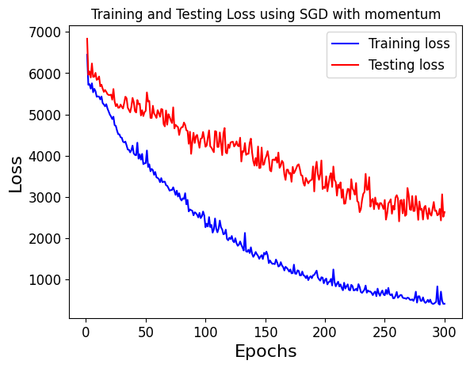

```python
class MLP_with_SGD_momentum(MLP):
    def __init__(self, sizes):
        super().__init__(sizes)
        self.velocity_w = [np.zeros_like(w) for w in self.weights]
        self.velocity_b = [np.zeros_like(b) for b in self.biases]

    def SGD_with_momentum_one_batch(self, mini_batch, eta, momentum):
        """Update parameters by sgd with momentum on a single mini batch."""
        grad_b = [np.zeros(b.shape) for b in self.biases]
        grad_w = [np.zeros(w.shape) for w in self.weights]

        # computes gradient for every training sample in the mini_batch
        for xi, yi in mini_batch:
            # db denotes dli/db for all bias, same for dw
            db, dw = self.backprop(xi, yi)

            # elementwise addition of grads of bias and weights
            grad_b = [nb+dnb for nb, dnb in zip(grad_b, db)]
            grad_w = [nw+dnw for nw, dnw in zip(grad_w, dw)]

        # Update velocities using momentum
        self.velocity_w = [momentum * v + eta / len(mini_batch) * dw for v, dw in zip(self.velocity_w, grad_w)]
        self.velocity_b = [momentum * v + eta / len(mini_batch) * db for v, db in zip(self.velocity_b, grad_b)]

        # Update weights and biases using the velocities
        self.weights = [w - v for w, v in zip(self.weights, self.velocity_w)]
        self.biases = [b - v for b, v in zip(self.biases, self.velocity_b)]

    def SGD_with_momentum(self, training_data, epochs, mini_batch_size, eta, momentum):
        '''Calls sgd_with_momentum_one_batch on every batch.'''
        # note training_data = zip(X_train, y_train).
        training_data = list(training_data) # turn zip to list
        n = len(training_data)

        train_loss = []
        test_loss = []
        for j in range(epochs):
            random.shuffle(training_data)

            #partitions into mini-batches
            mini_batches = [
                training_data[k:k+mini_batch_size]
                for k in range(0, n, mini_batch_size)]

            for mini_batch in mini_batches:
                self.SGD_with_momentum_one_batch(mini_batch, eta, momentum)
            print("Epoch {} complete".format(j))
            train_loss.append(self.evaluate(X_train, y_train))
            test_loss.append(self.evaluate(X_test, y_test))
        return (train_loss, test_loss)

mlp_momentum = MLP_with_SGD_momentum([12,50,50,1])
training_data = zip(X_train, y_train)
train_loss, test_loss = mlp_momentum.SGD_with_momentum(training_data, epochs = 300, mini_batch_size = 8, eta = 5e-5, momentum=0.4)
epochs = range(1, 301)
plt.plot(epochs, train_loss, 'b', label='Training loss')
plt.plot(epochs, test_loss, 'r', label='Testing loss')
plt.title('Training and Testing Loss using SGD with momentum')
plt.xlabel('Epochs')
plt.ylabel('Loss')
# plt.yscale('log')
plt.legend()
plt.show()
```

```python
'''Training and testing MSE and r squared for SGD with momentum.'''
print("training MSE", mlp_momentum.evaluate(X_train, y_train))
print("testing MSE", mlp_momentum.evaluate(X_test, y_test))
print( "training R squared", R_squared(mlp_momentum.predict(X_train), np.squeeze(y_train)))
print("testing R squared",R_squared(mlp_momentum.predict(X_test), np.squeeze(y_test)))
```

```
training MSE 413.2124111495202
testing MSE 2633.052411661047
training R squared 0.9281081281769219
testing R squared 0.4649349133730748
```

### (1.2.3) (index)

First define a function called add_quadratic_terms() to add quadratic terms to X.

Then defines ridge and apply it on three different ridge penalty: [1e-4, 1, 1000]

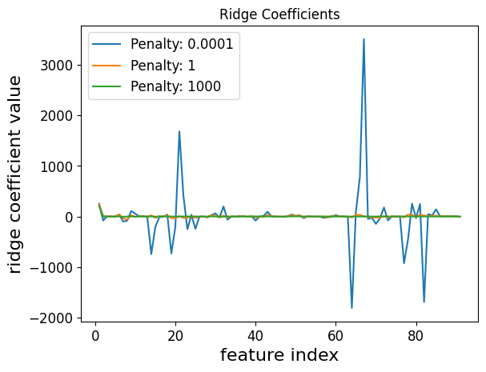

```python
def add_quadratic_terms(X):
    N, p = X.shape
    quadratic_terms = np.zeros((N, p + p*(p+1)//2))
    quadratic_terms[:, :p] = X
    col_idx = p
    for i in range(p):
        for j in range(i, p):
            quadratic_terms[:, col_idx] = X[:, i] * X[:, j]
            col_idx += 1
    return quadratic_terms

X_train_quadratic = add_quadratic_terms(X_train)

def ridge_estimate(X, y, penalty):
    N, D = X.shape
    X_aug = np.hstack([np.ones((N,1)), X]) # augmented training inputs of size N x (D+1)
    N_aug, D_aug = X_aug.shape
    I = np.identity(D_aug)
    I[0] = 0.0 # penalty excludes the bias term.
    beta_ridge = np.linalg.solve(X_aug.T @ X_aug + penalty * I, X_aug.T @ y)
    return beta_ridge

lambd_list = [1e-4, 1, 1000]
beta_ridge_list = []
for lambd in lambd_list:
    beta_ridge = ridge_estimate(X_train_quadratic, y_train, lambd)
    beta_ridge_list.append(beta_ridge)

for i in range(3):
    plt.plot(range(1,92), beta_ridge_list[i].reshape(-1), label=f'Penalty: {lambd_list[i]}')
plt.xlabel('feature index')
plt.title('Ridge Coefficients')
plt.ylabel('ridge coefficient value')
plt.legend()
```

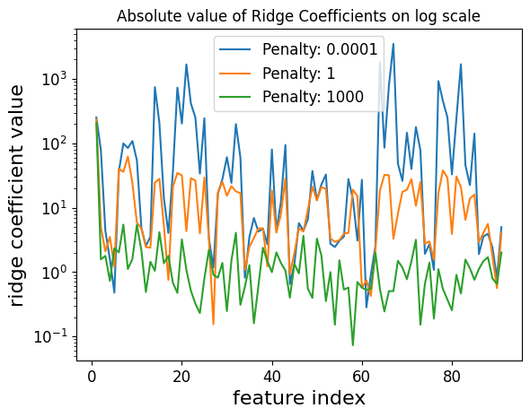

```python
for i in range(3):
    plt.plot(range(1,92), np.abs(beta_ridge_list[i].reshape(-1)), label=f'Penalty: {lambd_list[i]}')
plt.xlabel('feature index')
plt.title('Absolute value of Ridge Coefficients on log scale')
plt.ylabel('ridge coefficient value')
plt.legend()
plt.yscale('log')
```

```python
'''Evaluate each coefficient on train and testing set.'''
X_train_quadratic_aug = np.hstack([np.ones((X_train_quadratic.shape[0],1)), X_train_quadratic])
X_test_quadratic = add_quadratic_terms(X_test)
X_test_quadratic_aug = np.hstack([np.ones((X_test_quadratic.shape[0],1)), X_test_quadratic])
for i in range(3):
    print("penalty =", lambd_list[i])
    print(MSE(X_train_quadratic_aug @ beta_ridge_list[i], y_train), "training MSE")
    print(R_squared(y_train, X_train_quadratic_aug @ beta_ridge_list[i]), "training R squared")
    print(MSE(X_test_quadratic_aug @ beta_ridge_list[i], y_test), "testing MSE")
    print(R_squared(y_test, X_test_quadratic_aug @ beta_ridge_list[i]), "testing R squared")
```

```
penalty = 0.0001
3773.797662261361 training MSE
0.430565281940122 training R squared
5087.196180927667 testing MSE
0.2294574029845462 testing R squared
penalty = 1
3937.6050925892687 training MSE
0.4058481014623031 training R squared
4442.26437251612 testing MSE
0.3271433212934185 testing R squared
penalty = 1000
4951.0424503788645 training MSE
0.2529288228599468 training R squared
5372.333661564074 testing MSE
0.18626847001991353 testing R squared
```

Among these three ridge models, $\lambda=0.0001$ has the lowest training MSE and largest training $R^2$

$\lambda=1$ has the lowest testing MSE and largest testing $R^2$.

Use 5 fold to find optimal ridge penalty

```
No artists with labels found to put in legend.  Note that artists whose label start with an underscore are ignored when legend() is called with no argument.
```

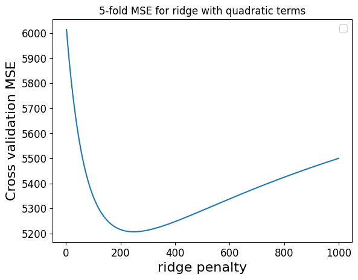

```python
# shuffle
p = rng.permutation(len(y_train))
X_train_quadratic_shuffled = X_train_quadratic[p, :]
y_train_shuffled = y_train[p]

# Five fold cross-validation
folds_indexes = cross_val_split(len(y_train), 5)
lambda_values = list(range(1, 1001))

# previously with x_train being pandas array, simply set X_train_fold = X_train_shuffled.drop(fold)
# now dealing with X_train_quadratic which is a numpy array, need to set train_indices = other 4 folds
mse_vals = []
for lambd in lambda_values:
    mse_scores = []
    for i, fold in enumerate(folds_indexes):
        # Split the data into training and validation
        X_val_quadratic_fold = X_train_quadratic_shuffled[fold, :]
        y_val_fold = y_train_shuffled[fold]

        train_indices = np.concatenate(folds_indexes[:i] + folds_indexes[i+1:])
        X_train_quadratic_fold = X_train_quadratic_shuffled[train_indices, :]
        y_train_fold = y_train_shuffled[train_indices]

        # Apply ridge regression on train_fold to get beta_ridge
        beta_ridge = ridge_estimate(X_train_quadratic_fold, y_train_fold, lambd)

        # turn X_val_fold into augmented matrix for evaluation
        N = X_val_quadratic_fold.shape[0]
        X_val_quadratic_aug = np.hstack([np.ones((N,1)), X_val_quadratic_fold])

        mse = MSE(X_val_quadratic_aug @ beta_ridge, y_val_fold)
        mse_scores.append(mse)
    mse_vals.append(np.mean(mse_scores))
plt.plot(lambda_values, mse_vals)
plt.xlabel('ridge penalty')
plt.title('5-fold MSE for ridge with quadratic terms')
plt.ylabel('Cross validation MSE')
plt.legend()
```

```python
optimal_ridge_penalty = lambda_values[np.argmin(mse_vals)]
optimal_ridge_penalty
```

```
248
```

```python
'''Check testing error of penalty = 248.'''
beta_ridge_248 = ridge_estimate(X_train_quadratic, y_train, 248)
MSE(X_test_quadratic_aug @ beta_ridge_248, y_test)
```

```
4798.060401253493
```

The best Ridge penalty for Ridge trained on X with quadratic features is 248. This is reasonable, as adding all the quadratic terms to X will make the model prone to overfit, and we expect good models to have a large penalty to suppress features that are highly correlated with others, hence 248 which is way larger than 1 and 0.0001.

Evaluate linear regression on the 12 original features only.

```python
def linear_regression(X, y):
    '''Simple linear regression.'''
    N, D = X.shape
    X_aug = np.hstack([np.ones((N,1)), X])
    beta_ml = np.linalg.solve(X_aug.T @ X_aug, X_aug.T @ y)
    return beta_ml

# turn X_test into augmented matrix
X_test_aug = np.hstack([np.ones((X_test.shape[0],1)), X_test])

# SLR on X_train and evaluate on X_test, then obtain MSE and R_squared
beta_slr = linear_regression(X_train, y_train)
print("Linear regression MSE and R squared on X_test")
print("MSE SLR on testing", MSE(X_test_aug @ beta_slr, y_test))
print("R squared SLR on testing", R_squared(y_test, X_test_aug @ beta_slr))
```

```
Linear regression MSE and R squared on X_test
MSE SLR on testing 5794.722718697619
R squared SLR on testing 0.12229044568996916
```

Now apply 5-fold ridge regression on original X_train to find optimal ridge penalty.

Here we expect optimal ridge penalty to be smaller, so we experiment with a list of penalties on log scale, ranging from $10^{-4}$ to $10^{2.5} \approx 316$

```
No artists with labels found to put in legend.  Note that artists whose label start with an underscore are ignored when legend() is called with no argument.
```

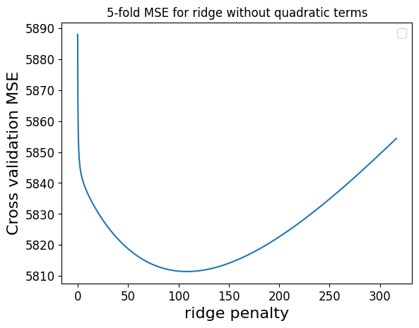

```python
# shuffle X_train (without quadratic terms)
p = rng.permutation(len(y_train))
X_train_shuffled = X_train[p, :]
y_train_shuffled = y_train[p]

# Five fold cross-validation
folds_indexes = cross_val_split(len(y_train), 5)
mse_vals = []
lambda_values = np.logspace(-4, 2.5, num=1000)
# this list covers lambda from 10^-4 to 10^2.5 on a log scale

for lambd in lambda_values:
    mse_scores = []
    for i, fold in enumerate(folds_indexes):
        # Split the data into training and validation
        X_val_fold = X_train_shuffled[fold, :]
        y_val_fold = y_train_shuffled[fold]

        train_indices = np.concatenate(folds_indexes[:i] + folds_indexes[i+1:])
        X_train_fold = X_train_shuffled[train_indices, :]
        y_train_fold = y_train_shuffled[train_indices]

        beta_ridge = ridge_estimate(X_train_fold, y_train_fold, lambd)

        # turn X_val_fold into augmented matrix for evaluation
        N = X_val_fold.shape[0]
        X_val_aug = np.hstack([np.ones((N,1)), X_val_fold])

        mse = MSE(X_val_aug @ beta_ridge, y_val_fold)
        mse_scores.append(mse)
    mse_vals.append(np.mean(mse_scores))

plt.plot(lambda_values, mse_vals)
plt.xlabel('ridge penalty')
plt.title('5-fold MSE for ridge without quadratic terms')
plt.ylabel('Cross validation MSE')
plt.legend()
```

```python
optimal_ridge_penalty = (lambda_values[np.argmin(mse_vals)])
optimal_ridge_penalty
```

```
109.1535935331391
```

We want to check on testing data and see if this is really the case:

```python
'''Same with slr (penalty = 0)'''
beta_ridge_109 = ridge_estimate(X_train, y_train, 109)
print( "MSE with penalty = 109: ", MSE(X_test_aug @ beta_ridge_109, y_test))
beta_ridge_0 = ridge_estimate(X_train, y_train, 0)
print( "MSE with penalty = 0(Same with SLR): ", MSE(X_test_aug @ beta_ridge_0, y_test))
```

```
MSE with penalty = 109:  5862.801486364213
MSE with penalty = 0(Same with SLR):  5794.722718697619
```

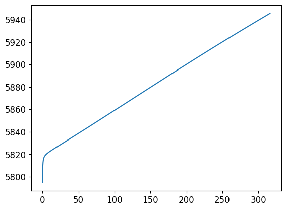

```python
'''Plot testing values for all lambdas we exanmined with 5-fold.'''
ridge_test_error = []
for l in lambda_values:
    beta_ridge_0 = ridge_estimate(X_train, y_train, l)
    ridge_test_error.append(MSE(X_test_aug @ beta_ridge_0, y_test))

plt.plot(lambda_values, ridge_test_error)
```

Using 5 fold cross validation, we see that the best Ridge penalty for Ridge model trained on the original X is 109. We expect a good Ridge model to balance between reducing variance (by regularizing the coefficients) and maintaining a reasonable level of bias. Therefore RIDGE trained on the original dataset X without correlated quadratic terms is good to have $\lambda$ smaller than X with quadratic terms. 109 here provides a good balance.

However with testing data, we see a different case, with testing error increasing almost linearly with penalty. In terms of testing MSE, penalty=0 (Simple Linear Regression) performs the best.

# (2) Task 2: Classification (index)

```python
cancerdf = pd.read_csv("brain_cancer_samples.csv")
cancer_test_df = pd.read_csv("brain_cancer_test.csv")
cancerdf.head()
```

|  | Patient ID | 2D Surface | Contour Size | Total Surface | Density | Diameter | Primary Axis | Shape Variation | Location | Eccentricity_Real | Eccentricity_Imag | Class |
| --- | --- | --- | --- | --- | --- | --- | --- | --- | --- | --- | --- | --- |
| 0 | 1 | 1325.5 | 160.124890 | 1518.5 | 0.872901 | 41.081371 | 36.290924 | 53.992371 | 2 | 6.750000e-17 | 1.101565 | 1 |
| 1 | 2 | 81.5 | 39.556349 | 88.0 | 0.926136 | 10.186708 | 8.801125 | 15.591203 | 2 | 8.950000e-17 | 1.462264 | 1 |
| 2 | 3 | 57177.0 | 912.607209 | 57611.0 | 0.992467 | 269.814784 | 234.644165 | 312.589264 | 4 | 5.390000e-17 | 0.880179 | 0 |
| 3 | 4 | 135.0 | 92.083260 | 206.0 | 0.655340 | 13.110581 | 6.568726 | 40.183521 | 3 | 3.700000e-16 | 6.035112 | 0 |
| 4 | 5 | 6653.0 | 1525.307779 | 84025.5 | 0.079178 | 92.037290 | 383.980133 | 402.407623 | 3 | 1.920000e-17 | 0.313504 | 1 |

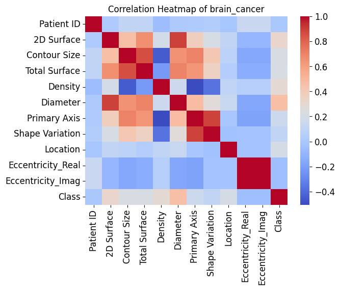

```python
import seaborn as sns
sns.heatmap(cancerdf.corr(), annot=False, fmt=".2f", cmap='coolwarm')
plt.title('Correlation Heatmap of brain_cancer')
```

We can clearly observe the following:

1. **Patient ID** is independent with everything else, and should be taken away (irrelevant).
2. **Class** (our target) has some correlation with **diameter**, and not much with any other feature.
3. **Contour size** is strongly correlated with **total surface** (0.86), **primary axis** and **shape variation** are highly correlated (0.89), **dimater** and **2d surface** are strongly correlated (0.9).
4. **Density** and **primary axis** has strong negative correlation (-0.5)

```python
# note I used ".values" so that the following are numpy arrays not pd dataframe
X_train = cancerdf.iloc[:, 1:-1].values # all columns except first(patient ID) and last
y_train = cancerdf.iloc[:, -1].values # all rows, last column only
print("X_train shape: ", X_train.shape)
print("y_train shape: ", y_train.shape)
X_test= cancer_test_df.iloc[:, 1:-1].values
y_test = cancer_test_df.iloc[:, -1].values
print("X_test shape: ", X_test.shape)
print("y_testshape: ", y_test.shape)
```

```
X_train shape:  (145, 10)
y_train shape:  (145,)
X_test shape:  (60, 10)
y_testshape:  (60,)
```

## (2.1) k-Nearest Neighbours (index)

Before applying KNN, we need to standardise both X_train and X_test by the mean and variance of X_train.

```python
X_test = standardise(X_test, X_train_=X_train)
X_train = standardise(X_train)
```

It can be interesting to visualize some feature pairs. I plot **density** against **contour size** in the following.

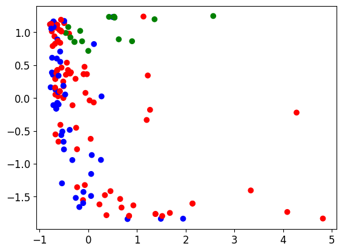

```python
from matplotlib.colors import ListedColormap
cm = plt.cm.RdBu
cm_bright = ListedColormap(['blue', 'red', 'green'])
plt.scatter(X_train[:, 1], X_train[:, 3], c=y_train, cmap=cm_bright)
# plt.scatter(X_test[:, 2], X_test[:, 3], c=y_test, cmap=cm_bright, alpha=0.25)
# plt.gca().set_xlim([-1, 2.5])
```

We will apply KNN to try to classify.

```python
def euclidian_distance(p, q):
    return np.sqrt(np.sum((p-q)**2, axis=1))

def k_neighbours(X_train, X_test, k=5, return_distance=False):
    '''for every x_test, return the k nearest index of x_train'''
    dist = []
    neigh_ind = []

    # compute distance from each point in X_test to all points in X_train
    point_dist = [euclidian_distance(i,X_train) for i in X_test]

    # determine which k training points are closest to each test point
    for row in point_dist:
        neighbors = sorted(enumerate(row), key=lambda x: x[1])
        neigh = neighbors[:k]

        ind_list = [i[0] for i in neigh]
        dist_list = [i[1] for i in neigh]

        neigh_ind.append(ind_list)
        dist.append(dist_list)

    # return distances together with indices of k nearest neighbouts
    if return_distance:
        return np.array(dist), np.array(neigh_ind)

    return np.array(neigh_ind)

def predict(X_train, y_train, X_test, k):
    neigh = k_neighbours(X_train, X_test, k)
    # each row is neighbors of one x_test

    # count number of occurences of label with np.bincount
    pred = []
    for n in neigh:
        labels = y_train[n]

        freq = np.bincount(labels)
        # print(freq)
        pred.append(np.argmax(freq))
    return pred

def micro_avg_accuracy(X_train, y_train, X_test, y_test, k=5):
    y_pred = predict(X_train, y_train, X_test, k=k)
    y_pred = np.array(y_pred)
    tp_total = 0
    tn_total = 0
    fp_total = 0
    fn_total = 0
    # Given that we have three classes 0,1 and 2
    for c in range(3):
        tp = np.sum((y_pred == c) & (y_test == c))
        tn = np.sum((y_pred != c) & (y_test != c))
        fp = np.sum((y_pred == c) & (y_test != c))
        fn = np.sum((y_pred != c) & (y_test == c))
        tp_total += tp
        tn_total += tn
        fp_total += fp
        fn_total += fn
    maa = (tp_total + tn_total) / (tp_total + tn_total + fp_total + fn_total)
    return maa
```

### (2.1.1) (index)

```python
def cross_validation_score(X_train, y_train, folds, k):
    scores = []
    p = rng.permutation(len(y_train))
    X_train_shuffled = X_train[p, :]
    y_train_shuffled = y_train[p]
    for i in range(len(folds)):
        train_indexes = set(range(len(y_train))) - set(folds[i])
        train_indexes = list(train_indexes)

        X_train_i = X_train_shuffled[train_indexes, :]
        y_train_i = y_train_shuffled[train_indexes]

        X_folds_i = X_train_shuffled[folds[i], :]
        y_folds_i = y_train_shuffled[folds[i]]

        score_i = micro_avg_accuracy(X_train_i, y_train_i, X_folds_i, y_folds_i, k)
        scores.append(score_i)
    return np.average(scores)

def choose_best_k(X_train, y_train, folds, k_range):
    k_scores = np.zeros((len(k_range),))

    for i, k in enumerate(k_range):
        k_scores[i] = cross_validation_score(X_train, y_train, folds, k)
        print(f'5-fold MAA k={k}: {k_scores[i]:.3f}')

    best_k_index = np.argmax(k_scores)
    return k_scores, k_range[best_k_index]

folds_indexes = np.split(np.arange(len(y_train)), 5) # use 5 folds
k_scores, best_k = choose_best_k(X_train, y_train, folds_indexes, np.arange(1, 31))
print('best_k:', best_k)
```

```
5-fold MAA k=1: 0.747
5-fold MAA k=2: 0.766
5-fold MAA k=3: 0.811
5-fold MAA k=4: 0.784
5-fold MAA k=5: 0.793
5-fold MAA k=6: 0.779
5-fold MAA k=7: 0.798
5-fold MAA k=8: 0.789
5-fold MAA k=9: 0.789
5-fold MAA k=10: 0.784
5-fold MAA k=11: 0.770
5-fold MAA k=12: 0.752
5-fold MAA k=13: 0.766
5-fold MAA k=14: 0.761
5-fold MAA k=15: 0.747
5-fold MAA k=16: 0.775
5-fold MAA k=17: 0.770
5-fold MAA k=18: 0.756
5-fold MAA k=19: 0.775
5-fold MAA k=20: 0.747
5-fold MAA k=21: 0.729
5-fold MAA k=22: 0.766
5-fold MAA k=23: 0.743
5-fold MAA k=24: 0.747
5-fold MAA k=25: 0.747
5-fold MAA k=26: 0.747
5-fold MAA k=27: 0.752
5-fold MAA k=28: 0.720
5-fold MAA k=29: 0.733
5-fold MAA k=30: 0.687
best_k: 3
```

```
No artists with labels found to put in legend.  Note that artists whose label start with an underscore are ignored when legend() is called with no argument.
```

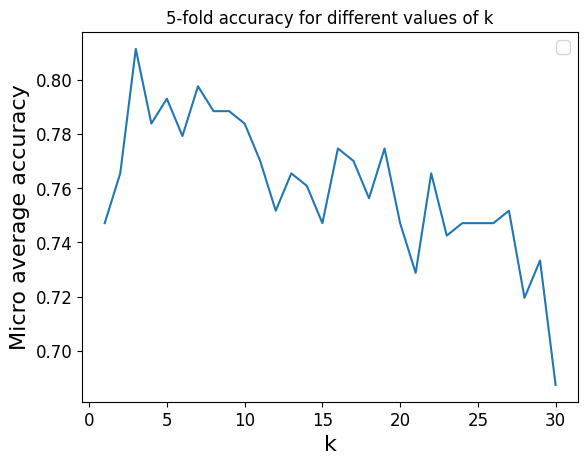

```python
plt.plot(np.arange(1, 31), k_scores)
plt.xlabel('k')
plt.title('5-fold accuracy for different values of k')
plt.ylabel('Micro average accuracy')
plt.legend()
```

Using k = 3 as our optimal knn hyperparameter, now evaluate on test set

```python
micro_avg_accuracy(X_train, y_train, X_test, y_test, k=3)
```

```
0.7777777777777778
```

Now identify the under-represented class in the training set, as well as finding the class weights for y_train.

```python
class_weights = {}
N = y_train.shape[0]
classi, counts = np.unique(y_train, return_counts=True)
print('the minority class is:', classi[np.argmin(counts)])
for c in np.unique(y_train):
    class_count = np.sum(y_train == c)
    class_weights[c] = class_count / N
class_weights
```

```
the minority class is: 2
```

```
{0: 0.32413793103448274, 1: 0.5517241379310345, 2: 0.12413793103448276}
```

Define the 6 metrics: macro-avg, micro-avg and weighted avg for accuracy and precision.  
Note weighted is in fact a form of macro, but with class weights, so to use weighted metric for the following function, need to set macro = True.  
The function returns (accuracy, precision) as a tuple.

```python
def avg_metrics(y_true, y_pred, class_weights, macro = True, weighted = False, print_each_class=False):
    '''Takes in np array y_true and y_pred, output 6 possible metrics.'''
    # note class_weighted avg is in fact macro avg plus class weights
    if macro == False and weighted == True:
        print("need to set macro=True for weighted avg")
        return
    y_pred = np.array(y_pred)
    tp_total, tn_total = 0, 0
    fp_total, fn_total = 0, 0
    acc_total, prec_total = 0, 0
    for c in range(3): # Given that we have three classes 0,1 and 2
        tp = np.sum((y_pred == c) & (y_true == c))
        tn = np.sum((y_pred != c) & (y_true != c))
        fp = np.sum((y_pred == c) & (y_true != c))
        fn = np.sum((y_pred != c) & (y_true == c))
        acc = (tp + tn) / (tp + tn + fp + fn)
        prec = tp / (tp + fp)
        recall = tp / (tp + fn)
        if print_each_class:
            print(f"class {c}")
            print("accuracy",round(acc, 3), "precision:",round(prec, 3), "recall:",round(recall, 3))
        if weighted:
            w = class_weights[c]
            acc, prec = acc * w, prec * w
            tp, tn, fp, fn = tp*w, tn*w, fp*w, fn*w
        acc_total += acc
        prec_total += prec
        tp_total += tp
        tn_total += tn
        fp_total += fp
        fn_total += fn
    if macro:
        if weighted:
            return (acc_total, prec_total)
        # return macro avg accuracy & precision
        return (acc_total / 3, prec_total / 3)
    else:
        # return micro avg accuracy & precision
        maa = (tp_total + tn_total) / (tp_total + tn_total + fp_total + fn_total)
        map = tp_total / (tp_total + fp_total)
        return (maa, map)
```

Use the 6 metrics to examine how our KNN classifier predicts the minority class in the training set.

To examine if the minority class label = 2 is truly underrepresented, we want to see the recall for each class, as underrepresented class typically has a high FN compared to TP, and hence a low recall = TP / (TP + FN)

We expect micro and macro accuracy to be the same, as it is basically how many times does y_pred agrees with y_true.

We expect micro precision to be slightly higher than macro precision, as macro is giving every class the same weight despite their relative frequencies, which could enlarge the error if the model is not predicting the minority class very well.

Additionally, we expect weighted precision to be higher than macro for the same reason.

```python
y_pred_train = np.array(predict(X_train, y_train, X_train, k=3))
print("classification metrics on training set")
macro_acc, macro_prec = avg_metrics(y_train, y_pred_train, class_weights, print_each_class=True)
micro_acc, micro_prec = avg_metrics(y_train, y_pred_train, class_weights, macro=False)
weighted_acc, weighted_prec = avg_metrics(y_train, y_pred_train, class_weights, weighted=True)
print("macro accuracy", macro_acc, "macro precision",macro_prec)
print("micro accuracy", micro_acc, "micro precision",micro_prec)
print("weighted accuracy", weighted_acc, "weighted precision", weighted_prec)
metrics_train = [macro_acc, micro_acc, macro_prec, micro_prec]
```

```
classification metrics on training set
class 0
accuracy 0.862 precision: 0.776 recall: 0.809
class 1
accuracy 0.848 precision: 0.862 recall: 0.862
class 2
accuracy 0.945 precision: 0.812 recall: 0.722
macro accuracy 0.8850574712643677 macro precision 0.8168367346938776
micro accuracy 0.8850574712643678 micro precision 0.8275862068965517
weighted accuracy 0.8647324613555292 weighted precision 0.8280964109781843
```

Based on the 6 metrics we obtained from the training set using kNN with k = 3, we observe the following:

We can see that both micro precision and weighted precision are indeed slightly higher than macro precision, but not too much difference.  
However, the minority class 2 actually has a pretty high accuracy of 0.945, comparing to the other two classes.

Precision is on the same level, but class 2 is indeed having a lower recall, due to the fact that the model is underrepresenting class 2 to a certain extent, creating false negatives for class 2 and false positives for class 0 and class 1, driving down their accuracies.

Before we move on to a weighted version of kNN, examine original kNN on testing set:

```python
class_weights_test = {}
for c in np.unique(y_test):
    class_count = np.sum(y_test == c)
    class_weights_test[c] = np.sum(y_test == c) / y_test.shape[0]
y_pred_test = np.array(predict(X_train, y_train, X_test, k=3))
print("classification metrics on testing set")
macro_acc, macro_prec = avg_metrics(y_test, y_pred_test, class_weights_test)
micro_acc, micro_prec = avg_metrics(y_test, y_pred_test, class_weights_test, macro=False)
weighted_acc, weighted_prec = avg_metrics(y_test, y_pred_test, class_weights_test, weighted=True)
print("macro accuracy", macro_acc, "macro precision",macro_prec)
print("micro accuracy", micro_acc, "micro precision",micro_prec)
print("weighted accuracy", weighted_acc, "weighted precision", weighted_prec)
metrics_test = [macro_acc, micro_acc, macro_prec, micro_prec]
```

```
classification metrics on testing set
macro accuracy 0.7777777777777777 macro precision 0.7387533875338753
micro accuracy 0.7777777777777778 micro precision 0.6666666666666666
weighted accuracy 0.7147222222222223 weighted precision 0.6750406504065042
```

Which reinforces in the idea that the model tends to underrepresent minority class 2 to some extent.

### (2.1.2) (index)

The problem with underrepresenting minority in kNN is that when we are looking at k cloesest neighbors of a point (especially with large k), it is overwhelmingly likely to be the large classes being the majority vote, despite the fact that a minority labeled point might be really close to the datapoint we want to predict.

Hence to compensate this, we want to give more emphasis on minority. The intuitive idea is to assign to each class a weight inversely proportional to their frequency in the set we are trying to predict.  
However, this is in fact giving too much emphasis to minority and driving down accuracy overall in reality. So I consider two methods below: take square root or cubic root of the inverse of class frequency as weights.

```python
'''Taking square root of inverse of class frequency.'''
def predict_weighted(X_train, y_train, X_test, k):
    neigh = k_neighbours(X_train, X_test, k)
    # each row is neighbors of one x_test
    pred = []
    for n in neigh:
        labels = y_train[n]
        freq = np.bincount(labels).astype(float) # freq of each class in k neighbors
        # apply weights sqrt of inverse to frequency
        freq[0] = np.sqrt(1/class_weights[0]) * freq[0]
        if len(freq) >= 2:
            freq[1] = np.sqrt(1/class_weights[1]) * freq[1]
        if len(freq) == 3:
            freq[2] = np.sqrt(1/class_weights[2]) * freq[2]
        pred.append(np.argmax(freq))
    return pred

# Apply on training set
y_pred_train = np.array(predict_weighted(X_train, y_train, X_train, k=3))
print("training set metrics weighted (sqrt of inverse freq)")
macro_acc, macro_prec = avg_metrics(y_train, y_pred_train, class_weights)
micro_acc, micro_prec = avg_metrics(y_train, y_pred_train, class_weights, macro=False)
weighted_acc, weighted_prec = avg_metrics(y_train, y_pred_train, class_weights, weighted=True)
print("macro accuracy", macro_acc, "macro precision",macro_prec)
print("micro accuracy", micro_acc, "micro precision",micro_prec)
print("weighted accuracy", weighted_acc, "weighted precision", weighted_prec)
metrics_train_sqrt = [macro_acc, micro_acc, macro_prec, micro_prec]
```

```
training set metrics weighted (sqrt of inverse freq)
macro accuracy 0.8896551724137932 macro precision 0.7998225498225499
micro accuracy 0.8896551724137931 micro precision 0.8344827586206897
weighted accuracy 0.8705826397146255 weighted precision 0.8474074387867492
```

```python
y_pred_test = np.array(predict_weighted(X_train, y_train, X_test, k=3))
print("testing set metrics weighted (sqrt of inverse freq)")
macro_acc, macro_prec = avg_metrics(y_test, y_pred_test, class_weights_test)
micro_acc, micro_prec = avg_metrics(y_test, y_pred_test, class_weights_test, macro=False)
weighted_acc, weighted_prec = avg_metrics(y_test, y_pred_test, class_weights_test, weighted=True)
print("macro accuracy", macro_acc, "macro precision",macro_prec)
print("micro accuracy", micro_acc, "micro precision",micro_prec)
print("weighted accuracy", weighted_acc, "weighted precision", weighted_prec)
metrics_test_sqrt = [macro_acc, micro_acc, macro_prec, micro_prec]
```

```
testing set metrics weighted (sqrt of inverse freq)
macro accuracy 0.7444444444444445 macro precision 0.5851851851851851
micro accuracy 0.7444444444444445 micro precision 0.6166666666666667
weighted accuracy 0.6797222222222222 weighted precision 0.6137037037037036
```

```python
'''Try cube root instead of sqrt.'''
def predict_weighted_cbrt(X_train, y_train, X_test, k):
    neigh = k_neighbours(X_train, X_test, k)
    # each row is neighbors of one x_test
    pred = []
    for n in neigh:
        labels = y_train[n]
        freq = np.bincount(labels).astype(float) # freq of each class in k neighbors
        # set type to float instead of int
        freq[0] = np.cbrt(1/class_weights[0]) * freq[0]
        if len(freq) >= 2:
            freq[1] = np.cbrt(1/class_weights[1]) * freq[1]
        if len(freq) == 3:
            freq[2] = np.cbrt(1/class_weights[2]) * freq[2]
        pred.append(np.argmax(freq))
    return pred
y_pred_train = np.array(predict_weighted_cbrt(X_train, y_train, X_train, k=3))
print("cube root weight on training")
macro_acc, macro_prec = avg_metrics(y_train, y_pred_train, class_weights)
micro_acc, micro_prec = avg_metrics(y_train, y_pred_train, class_weights, macro=False)
weighted_acc, weighted_prec = avg_metrics(y_train, y_pred_train, class_weights, weighted=True)
print("macro accuracy", macro_acc, "macro precision",macro_prec)
print("micro accuracy", micro_acc, "micro precision",micro_prec)
print("weighted accuracy", weighted_acc, "weighted precision", weighted_prec)
metrics_train_cbrt = [macro_acc, micro_acc, macro_prec, micro_prec]

y_pred_test = np.array(predict_weighted_cbrt(X_train, y_train, X_test, k=3))
print("cube root weight on testing")
macro_acc, macro_prec = avg_metrics(y_test, y_pred_test, class_weights_test)
micro_acc, micro_prec = avg_metrics(y_test, y_pred_test, class_weights_test, macro=False)
weighted_acc, weighted_prec = avg_metrics(y_test, y_pred_test, class_weights_test, weighted=True)
print("macro accuracy", macro_acc, "macro precision",macro_prec)
print("micro accuracy", micro_acc, "micro precision",micro_prec)
print("weighted accuracy", weighted_acc, "weighted precision", weighted_prec)
metrics_test_cbrt = [macro_acc, micro_acc, macro_prec, micro_prec]
```

```
cube root weight on training
macro accuracy 0.8896551724137932 macro precision 0.8058982683982685
micro accuracy 0.8896551724137931 micro precision 0.8344827586206897
weighted accuracy 0.8705826397146255 weighted precision 0.837102552619794
cube root weight on testing
macro accuracy 0.7777777777777777 macro precision 0.7387533875338753
micro accuracy 0.7777777777777778 micro precision 0.6666666666666666
weighted accuracy 0.7147222222222223 weighted precision 0.6750406504065042
```

Comparison of results:

```python
metrics_plot_train = np.array([metrics_train, metrics_train_sqrt, metrics_train_cbrt]).T
metrics_plot_test = np.array([metrics_test, metrics_test_sqrt, metrics_test_cbrt]).T
metrics_plot_test
```

```
array([[0.77777778, 0.74444444, 0.77777778],
       [0.77777778, 0.74444444, 0.77777778],
       [0.73875339, 0.58518519, 0.73875339],
       [0.66666667, 0.61666667, 0.66666667]])
```

Plot Metrics on three methods of kNN on training set

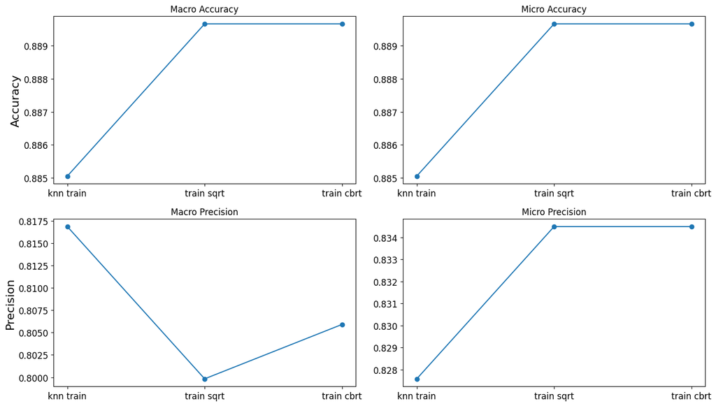

```python
experiments = ['knn train','train sqrt','train cbrt']
fig, axs = plt.subplots(2, 2, figsize=(14, 8))
axs[0, 0].plot(experiments, metrics_plot_train[0], marker='o', label='Macro Accuracy')
axs[0, 0].set_title('Macro Accuracy')
axs[0, 0].set_ylabel('Accuracy')
axs[0, 1].plot(experiments, metrics_plot_train[1], marker='o', label='Micro Accuracy')
axs[0, 1].set_title('Micro Accuracy')
axs[1, 0].plot(experiments, metrics_plot_train[2], marker='o', label='Macro Precision')
axs[1, 0].set_title('Macro Precision')
axs[1, 0].set_ylabel('Precision')
axs[1, 1].plot(experiments, metrics_plot_train[3], marker='o', label='Micro Precision')
axs[1, 1].set_title('Micro Precision')

plt.tight_layout()
plt.show()
```

Plot Metrics on three methods of kNN on testing set

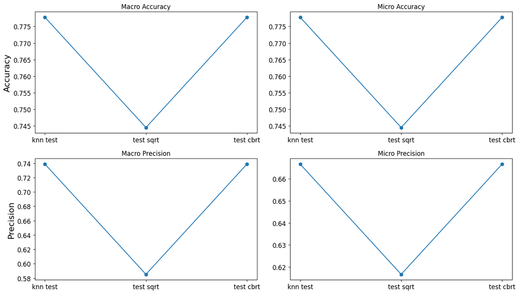

```python
experiments = ['knn test', 'test sqrt', 'test cbrt']
fig, axs = plt.subplots(2, 2, figsize=(14, 8))
axs[0, 0].plot(experiments, metrics_plot_test[0], marker='o', label='Macro Accuracy')
axs[0, 0].set_title('Macro Accuracy')
axs[0, 0].set_ylabel('Accuracy')
axs[0, 1].plot(experiments, metrics_plot_test[1], marker='o', label='Micro Accuracy')
axs[0, 1].set_title('Micro Accuracy')
axs[1, 0].plot(experiments, metrics_plot_test[2], marker='o', label='Macro Precision')
axs[1, 0].set_title('Macro Precision')
axs[1, 0].set_ylabel('Precision')
axs[1, 1].plot(experiments, metrics_plot_test[3], marker='o', label='Micro Precision')
axs[1, 1].set_title('Micro Precision')

plt.tight_layout()
plt.show()
```

I have ploted side by side macro&micro acc&prec for the orignal knn, knn weighted by $ 1/ \sqrt{class freq}$ and knn weighted by cube root of class freq.

Notice in the training set, both weighted kNN perform better in 3 of the 4 metrics.

In the testing set, original knn and cbrt kNN both perform better than sqrt kNN in all four metrics. However, there is no visible advantage to cbrt-weighted kNN comparing to original kNN, possibly because the testing set's size is quite small.

The reason I did not put a kNN scaled by just the inverse of class frequency is that that model performs even worse than sqrt version, over amplifying the minority class, driving down accuracy massively.

### (2.1.3) (index)

Implement 2 step kNN with k=3 on the first step, and k=1 on the second.

```python
'''Apply 2 step kNN on y_test.'''
y_train_step1 = np.where(y_train == 2, 1, y_train)
y_pred_test_step1 = np.array(predict(X_train, y_train_step1, X_test, k=3))
mask1 = (y_pred_test_step1 != 0)
mask_train = (y_train != 0)
y_pred_test_2step = np.zeros(y_test.shape)
y_pred_test_2step[mask1] = np.array(predict(X_train[mask_train], y_train[mask_train], X_test[mask1], k=1))
y_pred_test_2step
```

```
array([1., 1., 0., 1., 1., 0., 0., 1., 1., 1., 1., 1., 2., 1., 1., 2., 1.,
       1., 2., 1., 0., 1., 1., 0., 0., 0., 0., 2., 1., 1., 2., 1., 0., 1.,
       1., 1., 1., 1., 0., 1., 0., 0., 1., 1., 0., 1., 0., 1., 1., 1., 0.,
       1., 1., 1., 1., 1., 1., 1., 1., 1.])
```

```python
print("2 step kNN on testing")
macro_acc, macro_prec = avg_metrics(y_test, y_pred_test_2step, class_weights_test)
micro_acc, micro_prec = avg_metrics(y_test, y_pred_test_2step, class_weights_test, macro=False)
metrics_test_2step = [macro_acc, micro_acc, macro_prec, micro_prec]
print("macro accuracy", macro_acc, "macro precision",macro_prec)
print("micro accuracy", micro_acc, "micro precision",micro_prec)
```

```
2 step kNN on testing
macro accuracy 0.7888888888888889 macro precision 0.7444444444444445
micro accuracy 0.7888888888888889 micro precision 0.6833333333333333
```

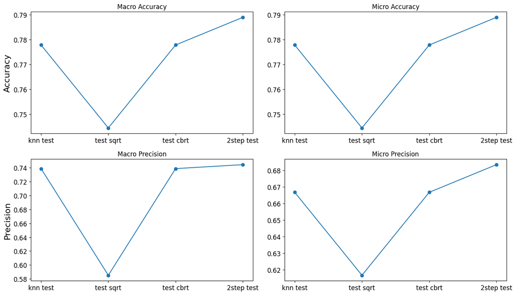

```python
metrics_plot = np.array([metrics_test, metrics_test_sqrt, metrics_test_cbrt, metrics_test_2step]).T
experiments = ['knn test',  'test sqrt', 'test cbrt','2step test']
fig, axs = plt.subplots(2, 2, figsize=(14, 8))
axs[0, 0].plot(experiments, metrics_plot[0], marker='o', label='Macro Accuracy')
axs[0, 0].set_title('Macro Accuracy')
axs[0, 0].set_ylabel('Accuracy')
axs[0, 1].plot(experiments, metrics_plot[1], marker='o', label='Micro Accuracy')
axs[0, 1].set_title('Micro Accuracy')
axs[1, 0].plot(experiments, metrics_plot[2], marker='o', label='Macro Precision')
axs[1, 0].set_title('Macro Precision')
axs[1, 0].set_ylabel('Precision')
axs[1, 1].plot(experiments, metrics_plot[3], marker='o', label='Micro Precision')
axs[1, 1].set_title('Micro Precision')

plt.tight_layout()
plt.show()
```

I plotted the testing accuracy of original kNN, kNN with sqrt weight, cbrt weight and 2 step kNN side by side.

Obviously, 2-step kNN is performing best in all 4 metrics for several reasons.

Firstly, the first step grouping cells to combined (class1 & class2) category avoids the underrepsentation of class2 issue. Also, cells of class1 anc class2 are both malignant, so have more similarities in between than with class0.

Secondly, kNN is making coarse predictions in the first step, then finer predictions in the second step, leading to better decision boundaries in general.

## (2.2) Logistic regression vs kernel logistic regression (index)

### (2.2.1) (index)

Implement logistic regression with an intercept $\beta_0$ and with a penalty term.

Note in this case we consider $\beta$ and $\beta_0$ separately. $$ h(x) = \frac{1}{1+e^{-(x^T \beta + \beta_0)}} \\ \\ \nabla_{\boldsymbol \beta} h(x) = \frac{x e^{-(x^T \beta + \beta_0)}}{(1+e^{-(x^T \beta + \beta_0)})^2} \\ \\ \nabla_{\boldsymbol \beta_0} h(x) = \frac{e^{-(x^T \beta + \beta_0)}}{(1+e^{-(x^T \beta + \beta_0)})^2} $$ So $$ \nabla_{\boldsymbol \beta} E(L) = \frac{1}{N}\sum_{i=1}^N (h_{\boldsymbol \beta}(\boldsymbol x^{(i)}) - y^{(i)})\boldsymbol x^{(i)} + \lambda \beta $$

and $$ \nabla_{\boldsymbol \beta_0} E(L) = \frac{1}{N}\sum_{i=1}^N (h_{\boldsymbol \beta}(\boldsymbol x^{(i)}) - y^{(i)} + \lambda \beta_0 $$

```python
def logistic(z, beta0):
    return 1 / (1 + np.exp(-z-beta0))

def propagate(X, y, beta, beta0, penalty):
    y_log = logistic(X @ beta, beta0).squeeze()
    n, p = X.shape
    mean_loss = - 1/n * (np.sum(y * np.log(y_log) + (1-y) * np.log(1 - y_log))) + penalty/2 * np.linalg.norm(beta)**2
    grad = np.mean(X.T * (y_log - y), axis=1).reshape(-1, 1) + penalty * beta
    grad0 = np.mean(y_log - y)
    mean_loss = np.squeeze(mean_loss)
    return grad, grad0, mean_loss

def optimise(X, y, beta, beta0, penalty, num_iterations=1000, learning_rate=0.1):
    mean_loss_history = []
    for i in range(num_iterations):
        grad, grad0, mean_loss = propagate(X, y, beta, beta0, penalty)
        beta = beta - grad * learning_rate
        beta0 = beta0 - grad0 * learning_rate
        if i % 100 == 0:
            mean_loss_history.append(mean_loss)
    return beta, beta0, mean_loss_history

y_train_logistic = np.where(y_train == 2, 1, y_train)
beta = np.zeros((X_train.shape[1], 1))
beta0 = 0
beta, beta0, mean_loss_history = optimise(X_train, y_train_logistic, beta, beta0, penalty=0.0025, num_iterations=5000)
```

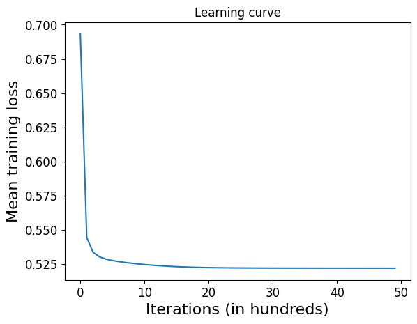

```python
plt.ylabel('Mean training loss')
plt.xlabel('Iterations (in hundreds)')
plt.title('Learning curve')
plt.plot(mean_loss_history)
```

Evaluate binary classification accuracy on train and test set.

```python
y_log = logistic(X_train @ beta, beta0)
y_pred_train_logistic = np.squeeze(y_log.round())
y_log = logistic(X_test @ beta, beta0)
y_pred_test_logistic = np.squeeze(y_log.round())
print("accuracy on train set:", np.sum(y_pred_train_logistic == y_train_logistic) / 145)
y_test_logistic = np.where(y_test == 2, 1, y_test)
print("accuracy on test set:", np.sum(y_pred_test_logistic == y_test_logistic) / 60)
```

```
accuracy on train set: 0.7862068965517242
accuracy on test set: 0.8333333333333334
```

Examine Precision-Recall curve and AUC for test set predictions.

```python
def roc_curve(y_true, y_log):
    # List of distinct values in y_log, sorted sorted in decreasing order
    thresholds = reversed(sorted(set(y_log)))
    precision_l, recall_l = [], []

    for threshold in thresholds:
        # Thresholding
        y_thresholded = (y_log >= threshold)

        tp = np.sum(y_true & y_thresholded)
        tn = np.sum((~y_true) & (~y_thresholded))
        fp = np.sum((~y_true) & y_thresholded)
        fn = np.sum(y_true & (~y_thresholded))
        prec = tp / (tp + fp)
        rec = tp / (tp + fn)
        precision_l.append(prec)
        recall_l.append(rec)

    # Compute AUC using Trapezoidal rule
    auc = np.trapz(precision_l, recall_l)
    return auc, precision_l, recall_l

auc, pl, rl = roc_curve(y_test_logistic, np.squeeze(y_log))
auc
```

```
0.8626400957509202
```

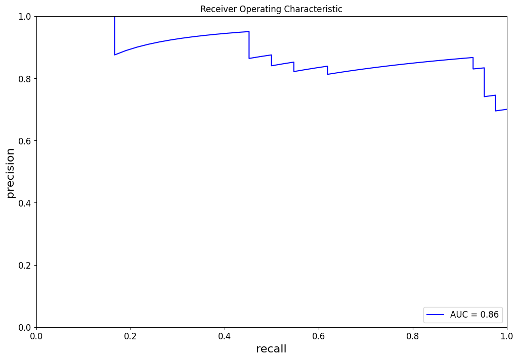

```python
plt.figure(figsize=(12,8))
plt.title(f'Receiver Operating Characteristic')
plt.plot(rl, pl, 'b', label=f'AUC = {auc:0.2f}')
plt.legend(loc='lower right')
plt.xlim([0, 1])
plt.ylim([0, 1])
plt.ylabel('precision')
plt.xlabel('recall')
plt.show()
```

### (2.2.2) (index)

We build a N $\times$ N matrix K, where $K_{ij} = kernel(x_i, x_j)$.

Then instead of finding $\beta$ such that $x_i^T \beta = log(p/(1-p))$, we instead look for $\beta$ such that $K_i^T \beta = log(p/(1-p))$, where $K_i = (k(x_i, x_1), k(x_i, x_2), \dots, k(x_i, x_N))$.

In this case, we define $$ p_{\boldsymbol \beta}(x^{(i)}) = \frac{1}{1 + exp(-K_i^T \beta)} $$ and define loss function to be $$ E(L) = \frac{1}{N}\sum_{i=1}^N y^{(i)} \log(p_{\boldsymbol \beta}(\boldsymbol x^{(i)})) + (1 - y^{(i)}) \log(1 - p_{\boldsymbol \beta}(\boldsymbol x^{(i)})) + \frac{\lambda}{2} \beta^T K \beta $$ Here we also include a ridge-like penalty term which regularizes how large $\beta$ can get. But we also want to add $K$ inside, like commonly done in SVM.

This is clearly convex, as the previous terms are just like logistic regression, only changing $x_i^T \beta$ to $K_i^T \beta$. Here the matrix $K$ can be computed with the kernel function before carrying out the optimisation, so this is obviously differentiable, with derivative given by $ \frac{1}{N}\sum_{i=1}^N (p_{\boldsymbol \beta}(\boldsymbol x^{(i)}) - y^{(i)})\boldsymbol K_{i}$

The last part is $\frac{\lambda}{2} \beta^T K \beta$, which has quadratic convexity since $K$ is positive semi-definite by definition. The derivative of this part is given by $\lambda K \beta$

Hence the derivative of the loss is given by $$ \nabla_{\boldsymbol \beta} E(L) = \frac{1}{N}\sum_{i=1}^N (p_{\boldsymbol \beta}(\boldsymbol x^{(i)}) - y^{(i)})\boldsymbol K_{i} + \lambda K \beta $$

### (2.2.3) (index)

```python
def laplacian_kernel(x, y, alpha):
    return np.exp(-alpha * np.linalg.norm(x - y, ord=1))

def kernelised_propagate(X, y, beta, beta0, penalty, K):
    y_log = logistic(K @ beta, beta0).squeeze()
    mean_loss = - np.mean(y * np.log(y_log) + (1-y) * np.log(1 - y_log)) + 0.5 * penalty * beta.T @ K @ beta
    grad = np.mean(K.T * (y_log - y), axis=1).reshape(-1, 1) + penalty * (K @ beta)
    grad0 = np.mean(y_log - y)
    mean_loss = np.squeeze(mean_loss)
    return grad, grad0, mean_loss

def predict_log_kernel(K, beta, beta0):
    y_log = logistic(K @ beta, beta0)
    return np.squeeze(y_log)

def optimise_kernel(X, y, beta, beta0, penalty, alpha, num_iterations=1000, learning_rate=0.1):
    N,_ = X.shape
    K = np.zeros((N, N))
    for i in range(N):
        for j in range(N):
            K[i, j] = laplacian_kernel(X[i], X[j], alpha)
    mean_loss_history = []
    for i in range(num_iterations):
        grad, grad0, mean_loss = kernelised_propagate(X, y, beta, beta0, penalty, K)
        beta = beta - grad * learning_rate
        beta0 = beta0 - grad0 * learning_rate
        if i % 100 == 0:
            mean_loss_history.append(mean_loss)
    return beta, beta0, mean_loss_history
```

Evaluate with $\alpha$ = 0.3

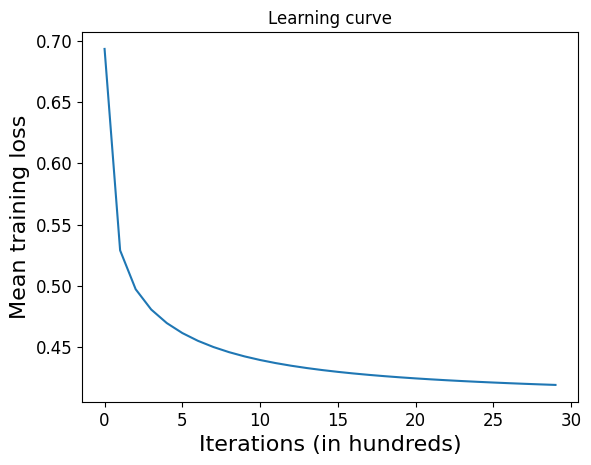

```python
beta = np.zeros((X_train.shape[0], 1))
beta0 = 0
beta, beta0, mean_loss_history = optimise_kernel(X_train, y_train_logistic, beta, beta0, penalty=0.0025, alpha = 0.3, num_iterations=3000)
plt.ylabel('Mean training loss')
plt.xlabel('Iterations (in hundreds)')
plt.title('Learning curve')
plt.plot(mean_loss_history)
```

```python
K_test = np.zeros((X_test.shape[0], X_train.shape[0]))
for i in range(X_test.shape[0]):
    for j in range(X_train.shape[0]):
        K_test[i,j] = laplacian_kernel(X_test[i], X_train[j], alpha=0.3)
y_log = predict_log_kernel(K_test, beta, beta0)
y_pred_test_kernel = np.squeeze(y_log.round())
y_test_logistic = np.where(y_test == 2, 1, y_test)
print("alpha = 0.3")
print("accuracy on test set:", np.sum(y_pred_test_kernel == y_test_logistic) / 60)
auc, pl, rl = roc_curve(y_test_logistic, np.squeeze(y_log))
print("auc=", auc)
```

```
alpha = 0.3
accuracy on test set: 0.8
auc= 0.8848180895695276
```

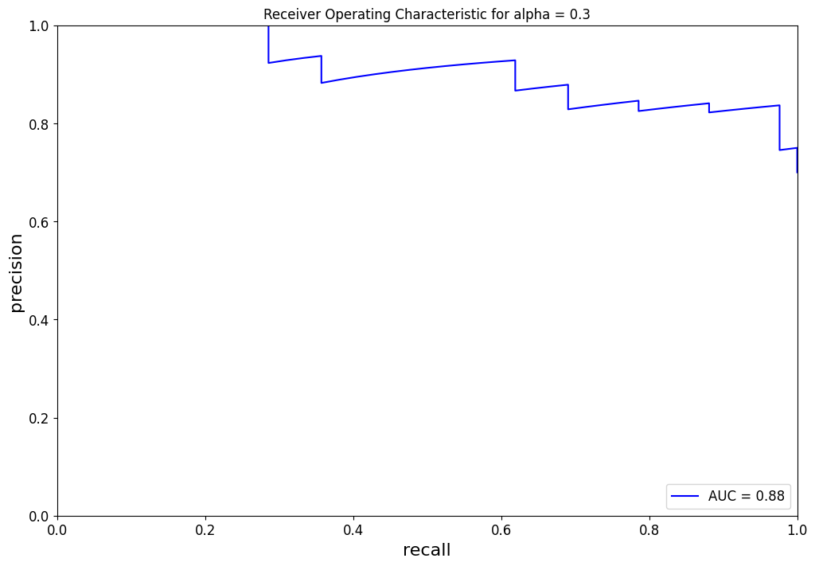

```python
plt.figure(figsize=(12,8))
plt.title(f'Receiver Operating Characteristic for alpha = 0.3')
plt.plot(rl, pl, 'b', label=f'AUC = {auc:0.2f}')
plt.legend(loc='lower right')
plt.xlim([0, 1])
plt.ylim([0, 1])
plt.ylabel('precision')
plt.xlabel('recall')
plt.show()
```

Evaluate with $\alpha$ = 100

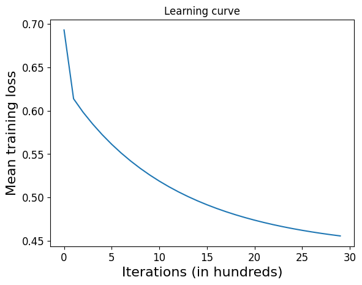

```python
beta = np.zeros((X_train.shape[0], 1))
beta0 = 0
beta, beta0, mean_loss_history = optimise_kernel(X_train, y_train_logistic, beta, beta0, penalty=0.0025, alpha = 100, num_iterations=3000)
plt.ylabel('Mean training loss')
plt.xlabel('Iterations (in hundreds)')
plt.title('Learning curve')
plt.plot(mean_loss_history)
```

```python
K_test = np.zeros((X_test.shape[0], X_train.shape[0]))
for i in range(X_test.shape[0]):
    for j in range(X_train.shape[0]):
        K_test[i,j] = laplacian_kernel(X_test[i], X_train[j], alpha=100)
y_log = predict_log_kernel(K_test, beta, beta0)
y_pred_test_kernel = y_log.round()
y_test_logistic = np.where(y_test == 2, 1, y_test)
print("alpha=100")
print("accuracy on test set:", np.sum(y_pred_test_kernel == y_test_logistic) / 60)
auc, pl, rl = roc_curve(y_test_logistic, y_log)
print("auc=", auc)
```

```
alpha=100
accuracy on test set: 0.7166666666666667
auc= 0.7948578746511077
```

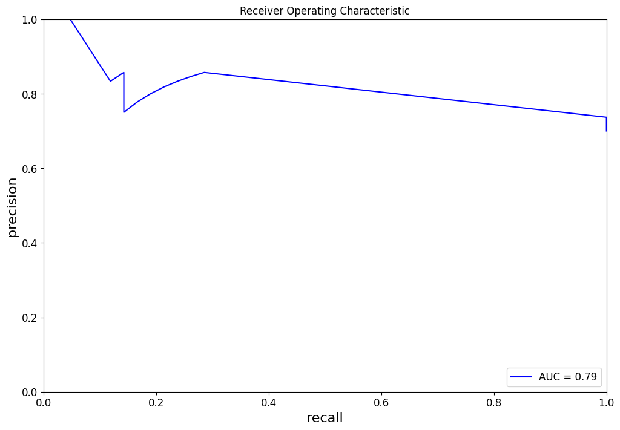

```python
plt.figure(figsize=(12,8))
plt.title(f'Receiver Operating Characteristic')
plt.plot(rl, pl, 'b', label=f'AUC = {auc:0.2f}')
plt.legend(loc='lower right')
plt.xlim([0, 1])
plt.ylim([0, 1])
plt.ylabel('precision')
plt.xlabel('recall')
plt.show()
```

```python
'''Problem with alpha=100.'''
print("y_log", y_log)
print(beta0)
print(K_test @ beta)
```

```
y_log [0.68397858 0.68397858 0.68397858 0.68397858 0.68397858 0.68397858
 0.68397858 0.68397858 0.68397858 0.68397858 0.68397858 0.68397858
 0.68397858 0.68397858 0.68397858 0.68397858 0.68397858 0.68397858
 0.76210324 0.68397858 0.68397858 0.68397858 0.7621077  0.68397858
 0.68397858 0.68397858 0.68397858 0.68397858 0.68397858 0.76210324
 0.68397858 0.68397858 0.68397858 0.68397858 0.68397858 0.68397858
 0.68397858 0.68397862 0.68397858 0.68397858 0.49188037 0.68397858
 0.68397858 0.68397858 0.76210324 0.68397858 0.68397858 0.68397858
 0.68397858 0.76210324 0.68397858 0.68397858 0.68397858 0.68397858
 0.68397858 0.68397858 0.68397858 0.68856959 0.68397858 0.8329627 ]
0.7721166069596634
[[ 8.52359212e-010]
 [ 1.58859380e-113]
 [-2.48407785e-069]
 [ 6.04715226e-051]
 [ 3.60638607e-042]
 [-7.25970373e-027]
 [-4.90547651e-045]
 [ 8.29854074e-034]
 [ 3.43530215e-018]
 [ 7.45131170e-017]
 [ 2.92374896e-018]
 [ 4.45507025e-031]
 [ 0.00000000e+000]
 [ 1.40250039e-042]
 [ 8.59646448e-088]
 [ 2.10232568e-011]
 [ 0.00000000e+000]
 [ 3.19127260e-137]
 [ 3.92128652e-001]
 [ 1.28417119e-019]
 [-2.41548429e-021]
 [ 1.52105454e-018]
 [ 3.92153254e-001]
 [-7.08142820e-016]
 [-2.71849859e-060]
 [-1.12466974e-010]
 [-3.85515706e-039]
 [-4.68980900e-058]
 [ 3.45666818e-053]
```

[output cut: 16 more lines]

```
 [ 4.10777755e-015]
 [-3.17681481e-018]
 [ 6.88384636e-022]
 [ 5.60503933e-015]
 [ 3.92128652e-001]
 [-4.42435212e-027]
 [ 1.43947495e-075]
 [ 9.51374325e-031]
 [ 2.75471229e-022]
 [ 2.14233082e-021]
 [ 1.80646128e-017]
 [-1.67894120e-023]
 [ 2.13238511e-002]
 [-5.44366662e-071]
 [ 8.34655089e-001]]
```

Discussion:

When setting $\alpha=100$, we have auc=0.79 and test accuracy = 0.716.

In fact, $k(x,y)$ is numerically very close to 0 for all data points $x,y$ from both the train and test set. Hence when we are using $K \beta + \beta_0$ to predict the log odd, we will get $K \beta + \beta_0 = 0 + \beta_0 = \beta_0$ for the vast majority of all datapoints.

Hence the resulting y_log is the same (0.6839) for all but a few points, and rounded to 1. Luckily, the y_test for binary classification also has a majority of 1, resulting in a test accuracy of 0.716, which may not look too bad but this is a bad model obviously.

On the other hand with $\alpha=0.3$, we have auc=0.88 and test accuracy = 0.8, both higher.

The y_log is also more diverse, and we have a better looking precision-recall curve. Comparing to the penalised logistic regression of 2.2.1, which has auc=0.86 and test accuracy = 0.833, which has slightly lower auc but slightly higher test accuracy.  
I would say the two models are performing similarly, may need to test on a wide range of larger datasets to find out.